# Part2

Import packages that will be used

```python
import pandas as pd
import seaborn as sns
import matplotlib.pyplot as plt
import numpy as np
from matplotlib.patches import Patch
from matplotlib.lines import Line2D
from sklearn.linear_model import LogisticRegression
from sklearn.preprocessing import StandardScaler
from sklearn.model_selection import train_test_split
from sklearn.pipeline import Pipeline
from sklearn.preprocessing import OneHotEncoder
from sklearn.compose import ColumnTransformer
from sklearn.metrics import accuracy_score, confusion_matrix, classification_report
```

In order to create reproducibility, np.random.seed(42) is used here.

```python
np.random.seed(42)
```

probability_density_fn is the variable created to store the f(x) =1/2 exp (−|x|). The parameter is num. "formula" follows the f(x). The probability_density_fn will return the formula.

```python
def probability_density_fn (num) :
  formula = (1/2) * np.exp(-abs(num))
  return formula
```

A function called "step" is created with parameters initial_value, num_of_sample, and s. The random_num is firstly defined as a vector with "N+1" numbers inside. As it hasn't been set up, there will be N+1 number of 0. Next, the first index of random_num will be the value of X0. This also the reason why N+1 instead of N. The X0 will be included in the first index, therefore to generate N random number + one initial value, N+1 will be generated.

previous_num is defined as random_num with current index minus 1. This will be used on x_star where the random samples will be generated. The x_star will generate one number with mean previous_num and standard deviation s.

ratio_formula is created to calculate the ratio (R= f(X*) / f(Xi-1)). "fx" and "fx_1" are calculated using the function of distribution created before. While in fx the parameter will be x_star, in "fx_1" the parameter will be previous_num.

"u" is created to generate a random uniform number between 0 and 1. To minimize the error, a log function is used. Based on the rules given, if log(u) less than log(ratio_formula), the x_star will be stored in random_num. Otherwise, the x_star will be rejected and the previous number will be stored again.

```python
def step (initial_value, num_of_sample, s):
  random_num = np.zeros(N+1)
  random_num[0] = X0

  for i in range(1,N+1) :
    previous_num = random_num[i-1]
    x_star= np.random.normal(loc= previous_num, scale =s, size= 1).item()

    fx = probability_density_fn(x_star)
    fx_1 = probability_density_fn(previous_num)
    ratio_formula = fx/fx_1

    u = np.random.uniform(size= 1)

    if np.log(u) < np.log(ratio_formula):
      random_num[i] = x_star
    elif np.log(u) >= np.log(ratio_formula):
      random_num[i] = random_num[i-1]

  return (random_num)
```

Define X0, N, and s, where X0 is the initial value which is 0, N is the positive integer, and s is the positive real number .

```python
N = 10000
s = 1
X0 = 0
```

The function "step" that has been created before is used here with intial_value = X0, num_of_sample = N, and s= s.This will be stored in answer_a

```python
answer_a =step(X0,N,s)
```

data_1 will stored the answer_a in data frame. Then actual_x_val will store 10000 numbers that evenly spaced between -7 and 7.

```python
data_1 = pd.DataFrame(answer_a)
actual_x_val = np.linspace(-7, 7, 10000)
```

Histogram of random samples with the kernel density will be shown and compared with the actual distribution function(probability_density_fn). The histogram, kernel, and distribution curve will be in green, red, and blue respectively. The graph shows that the random sample will looks similar to the actual distribution curve

Before doing the visualization, the answer_a must be stored in a data frame in a variable called “data_1”.

1. It will plot the figure with size = (8,6), 8 inches wide and inches height.
2. The "histplot" will plot the histogram, that use data_1. There’s stat='density' which ask to generate the density on the y axis rather than frequency count. Bins of 50 is used here, so the samples will be grouped into 50 intervals.
3. kernels is used to create kernel density. To change the color into red, then use the plt.setp that allow change the color manually.
4. It will use the actual_x_val created before, and input the actual_x_val into the probability_density_fn, to see the actual distribution with dark blue color. It's the dashed curve of actual distribution f(x).
5. The legend will be plot, based on the label of each plot
6. Title, x label, and y label will be customised.

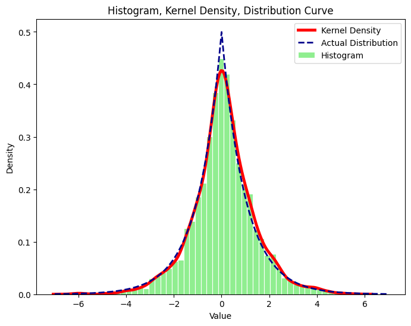

```python
plt.figure(figsize = (8,6))
sns.histplot(data_1, bins = 50, facecolor="lightgreen", fill= True, stat='density',edgecolor= 'white',label='Histogram')
kernels= sns.kdeplot(data_1, label = "Kernel Density",linewidth= 3.5)
plt.setp(kernels.lines, color='red')
plt.plot(actual_x_val, probability_density_fn(actual_x_val), color='darkblue', label='Actual Distribution', lw=2, linestyle ='--')
plt.legend()
plt.title("Histogram, Kernel Density, Distribution Curve")
plt.xlabel("Value")
plt.ylabel("Density")
plt.show()
```

The sample mean and standard deviation will be calculated

```python
a_sample_mean = answer_a.mean()
a_sample_sd = answer_a.std()
print("Sample_mean: ", a_sample_mean,"\nStandard Deviation:", a_sample_sd)
```

```
Sample_mean:  0.07910639097804344
Standard Deviation: 1.3159301702149588
```

part_b function will be created with parameter N, s, and J. chains_of_j will create a vector of list with length J, mean_of_j will create a vector with length J, where inside it will be 0. This is also implied on var_of_j.

Function from the part a can be used to generate random numbers, where new initial_values will be used (stored in numbers_list). chains_of_j[j] will store the random number with chain j (numbers_list). mean_of_j[j] is the mean of the random number in each chain. This implies the same on variance. Sample_var_w and sample_mean_m will calculate the mean and variance in overall average of all chains. The “calculation” variable will be used to calculate between_sample_variance. As well as “calculate” variable which is used to calculate R_hat. This function will return R_hat value.

```python
def part_b (N,s,J) :
  chains_of_j = [[]]
  mean_of_j = np.zeros(J)
  var_of_j = np.zeros(J)
  initial_values = np.zeros(J)

  for j in range(0,J) :
    initial_values = np.random.normal(loc=0, scale= 1,size= 1)
    numbers_list = step(initial_values,N,s)
    chains_of_j[j] = numbers_list

    mean_of_j[j] = np.mean(chains_of_j[j])
    var_of_j[j] = np.var(chains_of_j[j])

    sample_var_w = np.mean(var_of_j)
    sample_mean_m = np.mean(mean_of_j)
    calculation = (mean_of_j - sample_mean_m) **2
    between_sample_variance = np.mean(calculation)
    calculate = (between_sample_variance + sample_var_w) / sample_var_w
    R_hat = np.sqrt (calculate)

    return (R_hat)
```

st_dev is defined as a sequence that starts from 0.001 to 1 which increases by 0.005 for each value. It will be around 200 values that will be used in the visualisation. R_hat_value will be in vector form. At first, R_hat_bvalue will creates a list of None with the len of st_dev. Then it will use the function, answer_b is generated using the part_b function which includes parameter N = 2000, s= st_dev for all values in st_dev, and J=4. R_hat_value will be calculated through answer_b and it will be stored based on the length of st_dev.

```python
st_dev = np.arange(0.001,1.001, 0.005)
R_hat_value =[None] * len(st_dev)
for stdev in range(0, len(st_dev)):
  answer_b = part_b(2000, st_dev[stdev], 4)
  R_hat_value[stdev] = answer_b
```

In order to visualise the plot, the "result" variable will be created in the data frame forms which contain st_dev and R_hat_value. It also reset te index for visualisation purpose in later part. Then it will rename the columns with 'R_hat_value' where the original name is 'index' and it will change the 0 into 'st_dev'.

```python
result = pd.DataFrame(st_dev, R_hat_value).reset_index()
result =result.rename(columns = {'index' :'R_hat_value',0 :'st_dev'})
```

This is visualized using “result” as the data, where x axis will value st_dev and y axis will follow R_hat_value with purple color. It shows the value of R given the s= 0.001 to 1. There will be a red line which indicates the R value when it equals 1.05. The scale_y_continuos is used to set the limit of y axis so that it range from 1 to 2.5. It will also plot the legend, based on label that have been set before. The marker ='o' will create a line plot with point in each value of x. Then it will set in size 3.9 for better viz purpose.

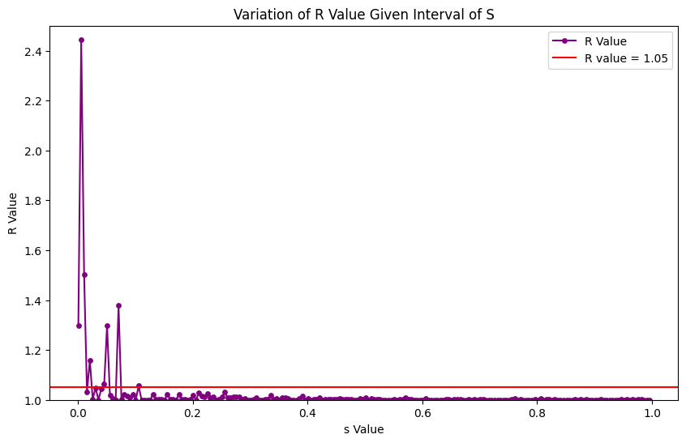

```python
plt.figure(figsize=(10,6))
plt.plot(result['st_dev'], result ['R_hat_value'], color='purple',marker='o', label='R Value',markersize=3.9)
plt.ylim(1,2.5)
plt.axhline(y= 1.05, color='red', label='R value = 1.05')
plt.title("Variation of R Value Given Interval of S")
plt.xlabel('s Value')
plt.ylabel('R Value')
plt.legend()
plt.show()
```

1. Create an empty list call "data".
2. Set variable call "name_of_csv" that contains 2000.csv, 2001.csv,2002.csv, 2003.csv, and 2004.csv.
3. The data from name_of_csv will be readed by pd.read_csv (read csv by using pandas), then combine it together into single data frame call "data" that contains years from 2000 to 2004.

```python
#1
data = [] #create an empty list
```

```python
#2
name_of_csv = [f"{x}.csv" for x in range (2000,2005)]
```

```python
#3
data_csv = [pd.read_csv(x,encoding="ISO-8859-1", low_memory= False) for x in name_of_csv]
```

```python
#3
data = pd.concat(data_csv,ignore_index= True)
```

There's high correlation between departure and arrival delay around 0.8945 which is a positive linear relationship. This means the higher the departure delay, the higher the arrival delay. It calculated by ignoring NA's values.

```python
data['DepDelay'].corr(data['ArrDelay'])
```

```
0.8945703267051959
```

```python
data.head()#to see the top 5 rows
```

|  | Year | Month | DayofMonth | DayOfWeek | DepTime | CRSDepTime | ArrTime | CRSArrTime | UniqueCarrier | FlightNum | ... | TaxiIn | TaxiOut | Cancelled | CancellationCode | Diverted | CarrierDelay | WeatherDelay | NASDelay | SecurityDelay | LateAircraftDelay |
| --- | --- | --- | --- | --- | --- | --- | --- | --- | --- | --- | --- | --- | --- | --- | --- | --- | --- | --- | --- | --- | --- |
| 0 | 2000 | 1 | 28 | 5 | 1647.0 | 1647 | 1906.0 | 1859 | HP | 154 | ... | 15 | 11 | 0 | NaN | 0 | NaN | NaN | NaN | NaN | NaN |
| 1 | 2000 | 1 | 29 | 6 | 1648.0 | 1647 | 1939.0 | 1859 | HP | 154 | ... | 5 | 47 | 0 | NaN | 0 | NaN | NaN | NaN | NaN | NaN |
| 2 | 2000 | 1 | 30 | 7 | NaN | 1647 | NaN | 1859 | HP | 154 | ... | 0 | 0 | 1 | NaN | 0 | NaN | NaN | NaN | NaN | NaN |
| 3 | 2000 | 1 | 31 | 1 | 1645.0 | 1647 | 1852.0 | 1859 | HP | 154 | ... | 7 | 14 | 0 | NaN | 0 | NaN | NaN | NaN | NaN | NaN |
| 4 | 2000 | 1 | 1 | 6 | 842.0 | 846 | 1057.0 | 1101 | HP | 609 | ... | 3 | 8 | 0 | NaN | 0 | NaN | NaN | NaN | NaN | NaN |

5 rows × 29 columns

```python
data.describe()#to get summary of data, in R it similar to summary()
```

|  | Year | Month | DayofMonth | DayOfWeek | DepTime | CRSDepTime | ArrTime | CRSArrTime | FlightNum | ActualElapsedTime | ... | Distance | TaxiIn | TaxiOut | Cancelled | Diverted | CarrierDelay | WeatherDelay | NASDelay | SecurityDelay | LateAircraftDelay |
| --- | --- | --- | --- | --- | --- | --- | --- | --- | --- | --- | --- | --- | --- | --- | --- | --- | --- | --- | --- | --- | --- |
| count | 3.054000e+07 | 3.054000e+07 | 3.054000e+07 | 3.054000e+07 | 2.982694e+07 | 3.054000e+07 | 2.976626e+07 | 3.054000e+07 | 3.054000e+07 | 2.976625e+07 | ... | 3.054000e+07 | 3.054000e+07 | 3.054000e+07 | 3.054000e+07 | 3.054000e+07 | 1.094507e+07 | 1.094507e+07 | 1.094507e+07 | 1.094507e+07 | 1.094507e+07 |
| mean | 2.002112e+03 | 6.486513e+00 | 1.572937e+01 | 3.941167e+00 | 1.347277e+03 | 1.341524e+03 | 1.496323e+03 | 1.504290e+03 | 1.623996e+03 | 1.252067e+02 | ... | 7.341157e+02 | 6.751763e+00 | 1.529962e+01 | 2.334830e-02 | 1.987034e-03 | 2.503534e+00 | 6.418064e-01 | 3.319752e+00 | 2.374421e-02 | 3.162058e+00 |
| std | 1.439959e+00 | 3.424745e+00 | 8.785188e+00 | 1.989989e+00 | 4.764815e+02 | 4.666019e+02 | 5.003515e+02 | 4.840637e+02 | 1.571646e+03 | 7.064183e+01 | ... | 5.720419e+02 | 2.856856e+01 | 1.191617e+01 | 1.510071e-01 | 4.453185e-02 | 1.601968e+01 | 8.317325e+00 | 1.459940e+01 | 1.196684e+00 | 1.609842e+01 |
| min | 2.000000e+03 | 1.000000e+00 | 1.000000e+00 | 1.000000e+00 | 1.000000e+00 | 0.000000e+00 | 1.000000e+00 | 0.000000e+00 | 1.000000e+00 | -7.190000e+02 | ... | 6.000000e+00 | 0.000000e+00 | 0.000000e+00 | 0.000000e+00 | 0.000000e+00 | 0.000000e+00 | 0.000000e+00 | -6.000000e+01 | 0.000000e+00 | 0.000000e+00 |
| 25% | 2.001000e+03 | 4.000000e+00 | 8.000000e+00 | 2.000000e+00 | 9.330000e+02 | 9.300000e+02 | 1.118000e+03 | 1.123000e+03 | 5.250000e+02 | 7.300000e+01 | ... | 3.180000e+02 | 4.000000e+00 | 1.000000e+01 | 0.000000e+00 | 0.000000e+00 | 0.000000e+00 | 0.000000e+00 | 0.000000e+00 | 0.000000e+00 | 0.000000e+00 |
| 50% | 2.002000e+03 | 7.000000e+00 | 1.600000e+01 | 4.000000e+00 | 1.332000e+03 | 1.330000e+03 | 1.524000e+03 | 1.527000e+03 | 1.172000e+03 | 1.060000e+02 | ... | 5.760000e+02 | 5.000000e+00 | 1.300000e+01 | 0.000000e+00 | 0.000000e+00 | 0.000000e+00 | 0.000000e+00 | 0.000000e+00 | 0.000000e+00 | 0.000000e+00 |
| 75% | 2.003000e+03 | 9.000000e+00 | 2.300000e+01 | 6.000000e+00 | 1.736000e+03 | 1.730000e+03 | 1.918000e+03 | 1.915000e+03 | 2.035000e+03 | 1.570000e+02 | ... | 9.780000e+02 | 7.000000e+00 | 1.800000e+01 | 0.000000e+00 | 0.000000e+00 | 0.000000e+00 | 0.000000e+00 | 0.000000e+00 | 0.000000e+00 | 0.000000e+00 |
| max | 2.004000e+03 | 1.200000e+01 | 3.100000e+01 | 7.000000e+00 | 2.750000e+03 | 2.400000e+03 | 2.955000e+03 | 2.400000e+03 | 9.912000e+03 | 1.777000e+03 | ... | 4.962000e+03 | 1.495000e+03 | 3.905000e+03 | 1.000000e+00 | 1.000000e+00 | 1.879000e+03 | 1.230000e+03 | 1.385000e+03 | 5.330000e+02 | 1.407000e+03 |

8 rows × 24 columns

1. "delayed_dep" will store data that contains flight with departure delay. It will filter the data, so the rows are only not cancelled and not diverted flights. It's defined as flight that delayed for 15 minutes or more (DepDelay>=15).
2. "Year" variable will be replaced with "Year" variable but in date format.

The reason why NA is not removed here, as it will be automatically dropped in by using filter (DepDelay >= 15). As only DepDelay will be used for calculation in the next steps. This also the reason to prevent losing much more data by droping NA that might not affect the calculation.

Delay is defined as all flights that arrive or depart exceed the scheduled time by 15 minutes or more (OAG wesbite).

```python
#1
delayed_dep = data[(data['Cancelled'] ==0) & (data['Diverted'] ==0) & (data['DepDelay'] >=15)] #delayed_dep contains only flight that is not cancelled and not diverted with departure delay is greater or equals to 15
```

```python
#2
delayed_dep['Year'] = pd.to_datetime(delayed_dep['Year'].astype(str) + '-01-01', format='%Y-%m-%d') #This to convert year into string, then combine it with '-01-01', after that make it into date format
```

Aggregation will be performed. It will use the data from "delayed_dep", then it will group it by "Year" and "DayOfWeek", that calculate the total departure delay(Total_delay), average departure delay(Avg_delay), and frequency of delay (Count_delay).

```python
delays_dep_per_day = (delayed_dep.groupby(['Year', 'DayOfWeek']).agg(
    Total_delay=('DepDelay', 'sum'),
    Avg_delay=('DepDelay', 'mean'),
    Count_delay=('DepDelay', 'count')).reset_index())

#This is group the delay_dep by Year and DayOfWeek, where the Total_delay is the sum of DepDelay, Avg_delay is the average of DepDelay, while Count_delay is the count of DepDelay which represents the frequency
```

```python
delays_dep_per_day.describe()#to see the summary of delays_dep_per_day
```

|  | Year | DayOfWeek | Total_delay | Avg_delay | Count_delay |
| --- | --- | --- | --- | --- | --- |
| count | 35 | 35.000000 | 3.500000e+01 | 35.000000 | 35.000000 |
| mean | 2001-12-31 19:12:00 | 4.000000 | 7.119139e+06 | 51.365362 | 137271.514286 |
| min | 2000-01-01 00:00:00 | 1.000000 | 3.666904e+06 | 45.621877 | 80376.000000 |
| 25% | 2001-01-01 00:00:00 | 2.000000 | 5.681191e+06 | 49.822775 | 114840.500000 |
| 50% | 2002-01-01 00:00:00 | 4.000000 | 6.725759e+06 | 51.384651 | 128941.000000 |
| 75% | 2003-01-01 00:00:00 | 6.000000 | 8.472750e+06 | 53.051480 | 159471.000000 |
| max | 2004-01-01 00:00:00 | 7.000000 | 1.190511e+07 | 58.033796 | 205141.000000 |
| std | NaN | 2.029199 | 1.992902e+06 | 2.656660 | 32387.694443 |

```python
delays_dep_per_day.tail()#to see the bottom 5 rows
```

|  | Year | DayOfWeek | Total_delay | Avg_delay | Count_delay |
| --- | --- | --- | --- | --- | --- |
| 30 | 2004-01-01 | 3 | 8836301.0 | 54.405025 | 162417 |
| 31 | 2004-01-01 | 4 | 10089215.0 | 54.338330 | 185674 |
| 32 | 2004-01-01 | 5 | 10136042.0 | 51.624684 | 196341 |
| 33 | 2004-01-01 | 6 | 6224767.0 | 48.668634 | 127901 |
| 34 | 2004-01-01 | 7 | 8974746.0 | 53.384882 | 168114 |

It will create a new column called "Yearly", with a date format of Year. So it will copy the 'Year' then convert in into year format. It will be only in year, for example 2000, 2001, etc

```python
delays_dep_per_day['Yearly'] = delays_dep_per_day['Year'].copy().dt.year #convert it from date format which is %Y-%m-%d year month date into year only
```

```python
delays_dep_per_day.tail()#to see how the Yearly looks like, shows the bottom 5 rows, so we can see the changes
```

|  | Year | DayOfWeek | Total_delay | Avg_delay | Count_delay | Yearly |
| --- | --- | --- | --- | --- | --- | --- |
| 30 | 2004-01-01 | 3 | 8836301.0 | 54.405025 | 162417 | 2004 |
| 31 | 2004-01-01 | 4 | 10089215.0 | 54.338330 | 185674 | 2004 |
| 32 | 2004-01-01 | 5 | 10136042.0 | 51.624684 | 196341 | 2004 |
| 33 | 2004-01-01 | 6 | 6224767.0 | 48.668634 | 127901 | 2004 |
| 34 | 2004-01-01 | 7 | 8974746.0 | 53.384882 | 168114 | 2004 |

for y that is from 2000 to 2004,

1. The "maxim_1" will contains the row index which contains the maximum of Avg_delay by using delays_dep_per_day data when the year is equal to y
2. The "minim_1" will contains the row index which contains the minimum of Avg_delay by using delays_dep_per_day data when the year is equal to y
3. custom_colour_1 => when the x is equal to maxim_1 (maximum index of row) it will be denoted as 'red', => when the x is equal to minim_1 (minimum index of row) it will be denoted as 'lightgreen' => otherwise it will denoted as 'lightgray'
4. x is inside the index from the delays_dep_per_day when the year is equals to y

then the custom_colour_1 that have been created before will be stored in colours_cus_1 6. ma_1 is using the delays_dep_per_day data and to locate the maxim (maximum index of row) and it will return the Avg_delay on that row index 7. mi_1 is using the delays_dep_per_day data and to locate the minim (minimum index of row) and it will return the Avg_delay on that row index 8. ma_1 will be stored in maxi_1, while mi_1 will be stored in mini_1 day_ma is using the delays_dep_per_day data and to locate the maxim_1 (maximum index of row) and it will return the DayOfWeek on that row index 9. day_mi is using the delays_dep_per_day data and to locate the minim_1 (minimum index of row) and it will return the DayOfWeek on that row index 10. day_ma will be stored in day_ma_1, while day_mi will be stored in day_mi_1

```python
colours_cus_1 =[]
maxi_1=[]
mini_1 =[]
day_ma_1=[]
day_mi_1=[]

for y in range (2000,2005):
    maxim_1= delays_dep_per_day[delays_dep_per_day['Yearly']==y]['Avg_delay'].idxmax()
    minim_1= delays_dep_per_day[delays_dep_per_day['Yearly']==y]['Avg_delay'].idxmin()
    custom_colour_1 = ['red' if x == maxim_1 else 'lightgreen' if x==minim_1 else 'lightgray' for x in (delays_dep_per_day[delays_dep_per_day["Yearly"]== y]).index]
    colours_cus_1.append(custom_colour_1)
    ma_1 = delays_dep_per_day.loc[maxim_1,'Avg_delay']
    mi_1 = delays_dep_per_day.loc[minim_1,'Avg_delay']
    day_ma = delays_dep_per_day.loc[maxim_1,'DayOfWeek']
    day_mi = delays_dep_per_day.loc[minim_1,'DayOfWeek']
    maxi_1.append(ma_1)
    mini_1.append(mi_1)
    day_ma_1.append(day_ma)
    day_mi_1.append(day_mi)
```

```python
colours_cus_1# it will be a list of list, where each list will contains color that can be used for visualisation purpose
```

```
[['lightgray',
  'lightgreen',
  'lightgray',
  'lightgray',
  'red',
  'lightgray',
  'lightgray'],
 ['lightgray',
  'lightgreen',
  'lightgray',
  'lightgray',
  'red',
  'lightgray',
  'lightgray'],
 ['lightgray',
  'red',
  'lightgray',
  'lightgray',
  'lightgray',
  'lightgreen',
  'lightgray'],
 ['lightgray',
  'lightgray',
  'lightgray',
  'lightgray',
  'lightgray',
  'lightgreen',
  'red'],
 ['red',
  'lightgray',
  'lightgray',
  'lightgray',
  'lightgray',
  'lightgreen',
  'lightgray']]
```

This will displays line chart by year, that shows the average departure delay from Mon (1) to Sun (7). The red color indicates the highest average delay, while green color shows the lowest average delay.

Tuesday might be good in 2000 and 2001 but the trend is changing since 2002, where it's increasing in delay average time.

However, it should be noted that the different of average delay from Monday to Sunday are small, which around 6 minutes differences.

[figure not shown]

```python
fig, ax = plt.subplots(2,3,figsize= (15,10))#to create 2 rows, 3 columns
fig.suptitle("Average Departure Delay by Day of Week", fontsize= 20) #plot the main title in the middle, with size 20
sns.lineplot(x= delays_dep_per_day[delays_dep_per_day['Year']== '2000-01-01']["DayOfWeek"],y= delays_dep_per_day[delays_dep_per_day['Year']== '2000-01-01']['Avg_delay'], ax=ax[0][0], color="black")
#create line graph, where the data is from delays_dep_per_day when the year is 2000 ('2000-01-01'). The x is from dayofweek, while the y axis is from Avg_delay , it is will be shown at row 0 col 0 (first row and first column)
ax[0][0].set_ylim(45,59)#set the y limit into 45 to 59 so that it standardize across all subplots
ax[0][0].set_ylabel("Departure Delay") #set y axis and name it as Departure Delay
ax[0][0].set_title("2000")#set the title as 2000, since it used data from that year
ax[0][0].scatter(delays_dep_per_day[delays_dep_per_day['Year']== '2000-01-01']["DayOfWeek"],delays_dep_per_day[delays_dep_per_day['Year']== '2000-01-01']['Avg_delay'], c =colours_cus_1[0])
#is to plot the point (scatter plot) using the data from delays_dep_per_day when the year is 2000 ('2000-01-01'). The x is from dayofweek, while the y axis is from Avg_delay , the colour of the point will follow the colours_cus_1 and using the index =0 (first list)
ax[0][0].text(5,58.3, round(maxi_1[0],1))#it will plot text or label at coordinate x=5, y =58.3, with maxi_1 and index 0 as the text. It will be rounded with one decimal point.
ax[0][0].text(2,51, round(mini_1[0],1))#it will plot text or label at coordinate x=2, y =51, with mini_1 and index 0 as the text. It will be rounded with one decimal point.
#above ax[0][0] means it will be plot in first row and first index

sns.lineplot(x= delays_dep_per_day[delays_dep_per_day['Year']== '2001-01-01']["DayOfWeek"],y= delays_dep_per_day[delays_dep_per_day['Year']== '2001-01-01']['Avg_delay'], ax=ax[0][1], color="black")
ax[0][1].set_ylim(45,59)
ax[0][1].set_ylabel("Departure Delay")
ax[0][1].set_title("2001")
ax[0][1].scatter(delays_dep_per_day[delays_dep_per_day['Year']== '2001-01-01']["DayOfWeek"],delays_dep_per_day[delays_dep_per_day['Year']== '2001-01-01']['Avg_delay'], c =colours_cus_1[1])
ax[0][1].text(5,53.5, round(maxi_1[1],1))
ax[0][1].text(2,48.5, round(mini_1[1],1))

sns.lineplot(x= delays_dep_per_day[delays_dep_per_day['Year']== '2002-01-01']["DayOfWeek"],y= delays_dep_per_day[delays_dep_per_day['Year']== '2002-01-01']['Avg_delay'], ax=ax[0][2], color="black")
ax[0][2].set_ylim(45,59)
ax[0][2].set_xlabel("Day Of Week")
ax[0][2].set_ylabel("Departure Delay")
ax[0][2].set_title("2002")
ax[0][2].scatter(delays_dep_per_day[delays_dep_per_day['Year']== '2002-01-01']["DayOfWeek"],delays_dep_per_day[delays_dep_per_day['Year']== '2002-01-01']['Avg_delay'], c =colours_cus_1[2])
ax[0][2].text(6,46, round(maxi_1[2],1))
ax[0][2].text(2,51.5, round(mini_1[2],1))

sns.lineplot(x= delays_dep_per_day[delays_dep_per_day['Year']== '2003-01-01']["DayOfWeek"],y= delays_dep_per_day[delays_dep_per_day['Year']== '2003-01-01']['Avg_delay'], ax=ax[1][0], color="black")
ax[1][0].set_ylim(45,59)
ax[1][0].set_xlabel("Day Of Week")
ax[1][0].set_ylabel("Departure Delay")
ax[1][0].set_title("2003")
ax[1][0].scatter(delays_dep_per_day[delays_dep_per_day['Year']== '2003-01-01']["DayOfWeek"],delays_dep_per_day[delays_dep_per_day['Year']== '2003-01-01']['Avg_delay'], c =colours_cus_1[3])
ax[1][0].text(6.5,53.5, round(maxi_1[3],1))
ax[1][0].text(5.65,49, round(mini_1[3],1))

sns.lineplot(x= delays_dep_per_day[delays_dep_per_day['Year']== '2004-01-01']["DayOfWeek"],y= delays_dep_per_day[delays_dep_per_day['Year']== '2004-01-01']['Avg_delay'], ax=ax[1][1], color="black")
ax[1][1].set_ylim(45,59)
ax[1][1].set_xlabel("Day Of Week")
ax[1][1].set_ylabel("Departure Delay")
ax[1][1].set_title("2004")
ax[1][1].scatter(delays_dep_per_day[delays_dep_per_day['Year']== '2004-01-01']["DayOfWeek"],delays_dep_per_day[delays_dep_per_day['Year']== '2004-01-01']['Avg_delay'], c =colours_cus_1[4])
ax[1][1].text(5.65,50, round(maxi_1[4],1))
ax[1][1].text(1,54.8, round(mini_1[4],1))

ax[1][2].axis('off') #as we only have 5 years data, then we only need 5 figure to plots, then the row 2 (index 1) column 3 (index 2) is not shown.

#to create a circle that will be used for legend, where the horizontal line on the circle will be set into white , the color will be light green if it's low avg delay, while it will be red if it's high avg delay
leg_1 = [Line2D ([0],[0], marker='o', color='w', markerfacecolor ='lightgreen', label = "Low Avg Dep Delay", markersize= 12),
        Line2D ([0],[0], marker='o', color='w', markerfacecolor ='red', label= "High Avg Dep Delay", markersize =12)]

#plot the legend using the legends created before, and it located at upper left
plt.legend(handles = leg_1, loc ="upper left")
plt.show()
```

1. ratio_delay_dofs use data dataframe, that will filter out the cancelled and diverted flight. Then it will create a new column call Total_Arr_Delay which contains binary number, 1 represents the departure delay is more or equals to 15, otherwise 0.

ratio_delay_dof will contains ratio_delay_dofs, then it will group by Year and DayOfWeek. Then, the total number of delay (Delay_flight), total number of delayed flight (Total_flight) will be calculated. It then create a new column call Ratio_of_delay, which calculate the ratio of delay (total of delayed flight/ total flight) which is rounded into 1 decimal point and it’s in percentag format

# 1

```python
ratio_delay_dofs = data[(data['Cancelled']==0) & (data['Diverted'] ==0)] #it only take data that is contains flight that not cancelled and not diverted
```

```python
ratio_delay_dofs['Total_Arr_Delay'] = np.where(ratio_delay_dofs['DepDelay']>=15,1,0) # it use ratio_delay_dofs data, when the DepDelay column have value more or equals to 15, in Total_Arr_Delay it stored as 1 otherwise 0.
```

```python
ratio_delay_dofs.head()#show the top 5 rows
```

|  | Year | Month | DayofMonth | DayOfWeek | DepTime | CRSDepTime | ArrTime | CRSArrTime | UniqueCarrier | FlightNum | ... | TaxiOut | Cancelled | CancellationCode | Diverted | CarrierDelay | WeatherDelay | NASDelay | SecurityDelay | LateAircraftDelay | Total_Arr_Delay |
| --- | --- | --- | --- | --- | --- | --- | --- | --- | --- | --- | --- | --- | --- | --- | --- | --- | --- | --- | --- | --- | --- |
| 0 | 2000 | 1 | 28 | 5 | 1647.0 | 1647 | 1906.0 | 1859 | HP | 154 | ... | 11 | 0 | NaN | 0 | NaN | NaN | NaN | NaN | NaN | 0 |
| 1 | 2000 | 1 | 29 | 6 | 1648.0 | 1647 | 1939.0 | 1859 | HP | 154 | ... | 47 | 0 | NaN | 0 | NaN | NaN | NaN | NaN | NaN | 0 |
| 3 | 2000 | 1 | 31 | 1 | 1645.0 | 1647 | 1852.0 | 1859 | HP | 154 | ... | 14 | 0 | NaN | 0 | NaN | NaN | NaN | NaN | NaN | 0 |
| 4 | 2000 | 1 | 1 | 6 | 842.0 | 846 | 1057.0 | 1101 | HP | 609 | ... | 8 | 0 | NaN | 0 | NaN | NaN | NaN | NaN | NaN | 0 |
| 5 | 2000 | 1 | 2 | 7 | 849.0 | 846 | 1148.0 | 1101 | HP | 609 | ... | 24 | 0 | NaN | 0 | NaN | NaN | NaN | NaN | NaN | 0 |

5 rows × 30 columns

```python
ratio_delay_dof = (ratio_delay_dofs.groupby(["Year", "DayOfWeek"]).agg(
    Delay_flight = ('Total_Arr_Delay', 'sum'),
    Total_flight = ('Total_Arr_Delay','count')).reset_index())

#This is group the ratio_delay_dofs by Year and DayOfWeek, where the Delay_flight is the sum of Total_Arr_Delay, while Total_flight is the count of Total_Arr_delay which represents the frequency
```

```python
ratio_delay_dof['Ratio_of_delay'] = round(ratio_delay_dof['Delay_flight'] *100/ratio_delay_dof['Total_flight'],1)
#it will create a new column call Ratio_of_delay inside ratio_delay_dof dataframe
#it's calculated with ratio_delay_dof data, where the Delay_flight is divided by Total_flight and times 100 so that it could be shown in percentage format
#then it will be rounded into one decimal point
```

```python
ratio_delay_dof.head()
```

|  | Year | DayOfWeek | Delay_flight | Total_flight | Ratio_of_delay |
| --- | --- | --- | --- | --- | --- |
| 0 | 2000 | 1 | 153032 | 795489 | 19.2 |
| 1 | 2000 | 2 | 132373 | 794933 | 16.7 |
| 2 | 2000 | 3 | 146808 | 799738 | 18.4 |
| 3 | 2000 | 4 | 186259 | 797754 | 23.3 |
| 4 | 2000 | 5 | 205141 | 799240 | 25.7 |

```python
#maxi=ratio_delay_dof['Ratio_of_delay'].idxmax()
#mini = ratio_delay_dof['Ratio_of_delay'].idxmin()

colours_cus =[]#create empty list
# maxi=[]
# mini=[]
# for y in range (2000,2005):
#     maxim= ratio_delay_dof[ratio_delay_dof['Year']==y]['Ratio_of_delay'].idxmax()
#     maxi.append(maxim)
#     minim= ratio_delay_dof[ratio_delay_dof['Year']==y]['Ratio_of_delay'].idxmin()
#     mini.append(minim)
#     custom_colour_2 = ['red' if x == maxi else 'green' if x==mini else 'gray' for x in (ratio_delay_dof[ratio_delay_dof["Year"]== y]).index]
#     colours_cus.append(custom_colour_2)

maxi=[]#create empty list
mini=[]#create empty list
#for y that is from 2000 to 2004,
# the "maxim" will contains the row index which contains the maximum of Ratio_of_delay by using ratio_dela_dof data when the year is equal to y
# the "minim" will contains the row index which contains the minimum of Ratio_of_delay by using ratio_dela_dof data when the year is equal to y
#custom_colour_2 => when the x is equal to maxim (maximum index of row) it will be denoted as 'red',
#                => when the x is equal to minim (minimum index of row) it will be denoted as 'green'
#                => otherwise it will denoted as 'gray'
# x is inside the index from the ratio_delay_dof when the year is equals to y
#then the custom_colour_2 that have been created before will be stored in colours_cus
#ma is using the ratio_delay_dof data and to locate the maxim (maximum index of row) and it will return the Ratio_of_delay on that row index
#mi is using the ratio_delay_dof data and to locate the minim (minimum index of row) and it will return the Ratio_of_delay on that row index
#ma will be stored in maxi, while mi will be stored in mini

for y in range (2000,2005):
    maxim= ratio_delay_dof[ratio_delay_dof['Year']==y]['Ratio_of_delay'].idxmax()
    minim= ratio_delay_dof[ratio_delay_dof['Year']==y]['Ratio_of_delay'].idxmin()
    custom_colour_2 = ['red' if x == maxim else 'green' if x==minim else 'gray' for x in (ratio_delay_dof[ratio_delay_dof["Year"]== y]).index]
    colours_cus.append(custom_colour_2)
    ma = ratio_delay_dof.loc[maxim,'Ratio_of_delay']
    mi = ratio_delay_dof.loc[minim,'Ratio_of_delay']
    maxi.append(ma)
    mini.append(mi)
```

```python
# custom_colour_2 = ['green' if x == mini else 'red' if x == maxi else 'gray' for x in (ratio_delay_dof[ratio_delay_dof["Year"]== 2000]).index]
#custom_colour_2 = ['green' if x == mini else 'red' if x == maxi else 'gray' for x in enumerate(ratio_delay_dof[ratio_delay_dof["Year"]== 2000])]
```

```python
colours_cus
```

```
[['gray', 'green', 'gray', 'gray', 'red', 'gray', 'gray'],
 ['gray', 'green', 'gray', 'gray', 'red', 'gray', 'gray'],
 ['gray', 'green', 'gray', 'gray', 'red', 'gray', 'gray'],
 ['gray', 'green', 'gray', 'gray', 'red', 'gray', 'gray'],
 ['gray', 'gray', 'gray', 'gray', 'red', 'green', 'gray']]
```

This will visualise the ratio of departure delay in each day, by year. It will highlight the highest and lowest ratio with red and green colour respectively. It will show label near the bar chart only if it’s the highest or the lowest ratio.

Frequency of delay isn’t a good measure. High frequency of delays just shows that delay is happen frequently on that day, which ignores the total number of flights. High frequency of delay might occur due to high number of flights and vice versa. Therefore, ratio must be calculated and be shown.

Friday have the highest ratio of departure delay. The biggest difference between ratio of departure delay is in 2000, where it’s around 9 % difference that indicates delay likely to be happen more in Friday rather than the lowest ratio day.

It can be seen Tuesday have low ratio of delay in 2000 -2003. While departure delay in Saturday is as low as Tuesday in 2003. In 2004, Saturday become the lowest ratio of delay.

[figure not shown]

```python
fig, ax = plt.subplots(2,3, figsize= (10,6)) #2 rows, 3 columns
ax= ax.flatten() #without this to access the axes is need [0][0] but after using this .flatten() it will allow us to use [0]
plt.suptitle ('Departure Delay Ratio (%) by Day of Week in 2000 - 2004', fontsize=15) #plot the title in the middle
sns.barplot(data=ratio_delay_dof [ratio_delay_dof["Year"]== 2000], x="DayOfWeek", y="Ratio_of_delay", ax= ax[0],hue='DayOfWeek', palette=colours_cus[0], legend=False)
#plot the barplot with the ratio_delay_dof data when the Year is in 2000, with DayOfWeek as x axis, Ratio_of_delay as Y axis, and it will be coloured based on DayOfWeek.
#It then using the colour_cus[0], that contains the list of colour whether it's gray, red, or green. It will take the first list (index 0) of the colour_cus. Then the legend won't be shown as it will cover up the graph
ax[0].set_ylim(0,28) #it will set the y limit from 0 to 28 so that across the figures, it will be standardized
ax[0].set_xlabel('')
ax[0].set_ylabel('Ratio of Delay')
ax[0].text(0.4,17.5, f"{mini[0]}%") #it will make a label on the top of bar chart, which is the minimum of the ratio_of_delay values that is stored in mini (when index = 0) then it will be written with %.
ax[0].text(3.4,26, f"{maxi[0]}%")#it will make a label on the top of bar chart, which is the maximum of the ratio_of_delay values that is stored in maxi (when index = 0) then it will be written with %.
sns.barplot(data=ratio_delay_dof [ratio_delay_dof["Year"]== 2001], x="DayOfWeek", y="Ratio_of_delay", ax= ax[1], color="red",hue='DayOfWeek', palette=colours_cus[1],legend=False)
ax[1].set_ylim(0,28)
ax[1].set_xlabel('')
ax[1].set_ylabel('')
ax[1].text(0.4,14.5, f"{mini[1]}%")
ax[1].text(3.4,21.5, f"{maxi[1]}%")
sns.barplot(data=ratio_delay_dof [ratio_delay_dof["Year"]== 2002], x="DayOfWeek", y="Ratio_of_delay", ax= ax[2], color="green", hue='DayOfWeek', palette=colours_cus[2],legend=False)
ax[2].set_ylim(0,28)
ax[2].set_xlabel('Day of Week')
ax[2].set_ylabel('')
ax[2].text(0.4,12.5, f"{mini[2]}%")
ax[2].text(3.4,17.5, f"{maxi[2]}%")
sns.barplot(data=ratio_delay_dof [ratio_delay_dof["Year"]== 2002], x="DayOfWeek", y="Ratio_of_delay", ax= ax[3], color="yellow",hue='DayOfWeek', palette=colours_cus[3],legend=False)
ax[3].set_ylim(0,28)
ax[3].set_xlabel('Day of Week')
ax[3].set_ylabel('Ratio of Delay')
ax[3].text(4.4,12.5, f"{mini[3]}%")
ax[3].text(0.4,12.5, f"{mini[3]}%")
ax[3].text(3.4,17.5, f"{maxi[3]}%")
sns.barplot(data=ratio_delay_dof [ratio_delay_dof["Year"]== 2002], x="DayOfWeek", y="Ratio_of_delay", ax= ax[4], color="black",hue='DayOfWeek', palette=colours_cus[4],legend=False)
ax[4].set_ylim(0,28)
ax[4].set_xlabel('Day of Week')
ax[4].set_ylabel('')
ax[4].text(4.4,12.5, f"{mini[4]}%")
ax[4].text(3.4,17.5, f"{maxi[4]}%")
ax[5].axis('off')

leg_notes = [Patch(facecolor = "green", edgecolor ="white", label="Low Dep Delay Ratio"),
            Patch(facecolor = "red", edgecolor= "white", label ="High Dep Delay Ratio")]
#this is to create manually the legend, where the color will be green and red to represents the Low Dep Delay Ratio and High Dep Delay Ratio respectively.
plt.legend(handles = leg_notes, loc = "center") #the legend will be plotted using the leg_notes, that is located in the center
plt.show()
```

“delayed_arr” will store data that contains flight with arrival delay. This is calculated when flight have arrival delay more than or equals to 15 minutes (ArrDelay>=15) and the departure delay is less than 15 minutes (DepDelay <15). This have been done to avoid double counting, as there’s high correlation between arrival delay and departure delay. To avoid this, arrival delay is counted when the delay is not caused by departure delay.

As not all data is used, it will select some columns. Here it will use only data when the flight is not cancelled and not diverted7.

```python
delayed_arr = data[(data['Cancelled'] ==0) & (data['Diverted'] ==0) & (data['DepDelay'] <15) & (data['ArrDelay'] >=15)] #delayed_arr contains only flight that is not cancelled and not diverted with departure delay is less than 15 minutes, while arrival delay is more than or equals to 15 minutes. This have been done due to high correlation between departure delay and arrival delay
```

```python
delayed_arr['Year'] = pd.to_datetime(delayed_arr['Year'].astype(str) + '-01-01', format='%Y-%m-%d') #This to convert year into string, then combine it with '-01-01', after that make it into date format
```

Aggregation will be performed. It will use the data from “delayed_arr”, then it will group it by “Year” and “DayOfWeek”, that calculate the total arrival delay(Total_delay), average arrival delay(Avg_delay), and frequency of delay (Count_delay).

```python
delays_per_day = (delayed_arr.groupby(['Year', 'DayOfWeek']).agg(
    Total_delay=('ArrDelay', 'sum'),
    Avg_delay=('ArrDelay', 'mean'),
    Count_delay=('ArrDelay', 'count')).reset_index())

#This is group the delayed_arr by Year and DayOfWeek, where the Total_delay is the sum of ArrDelay, Avg_delay is the average of ArrDelay, while Count_delay is the count of ArrDelay which represents the frequency
```

```python
delays_per_day['Yearly'] = delays_per_day['Year'].copy().dt.year #convert it from date format which is %Y-%m-%d year month date into year only
```

```python
colours_cus_3 =[]
maxi_3=[]
mini_3 =[]
day_ma_3=[]
day_mi_3=[]

for y in range (2000,2005):
    maxim_3= delays_per_day[delays_per_day['Yearly']==y]['Avg_delay'].idxmax()
    minim_3= delays_per_day[delays_per_day['Yearly']==y]['Avg_delay'].idxmin()
    custom_colour_3 = ['red' if x == maxim_3 else 'lightgreen' if x==minim_3 else 'lightgray' for x in (delays_per_day[delays_per_day["Yearly"]== y]).index]
    colours_cus_3.append(custom_colour_3)
    ma_3 = delays_per_day.loc[maxim_3,'Avg_delay']
    mi_3 = delays_per_day.loc[minim_3,'Avg_delay']
    day_ma_ = delays_per_day.loc[maxim_3,'DayOfWeek']
    day_mi_ = delays_per_day.loc[minim_3,'DayOfWeek']
    maxi_3.append(ma_3)
    mini_3.append(mi_3)
    day_ma_3.append(day_ma_)
    day_mi_3.append(day_mi_)

#for y that is from 2000 to 2004,
# the "maxim_3" will contains the row index which contains the maximum of Arr_delay by using delays_per_day data when the year is equal to y
# the "minim_3" will contains the row index which contains the minimum of Arr_delay by using delays_per_day data when the year is equal to y
#custom_colour_3 => when the x is equal to maxim_3 (maximum index of row) it will be denoted as 'red',
#                => when the x is equal to minim_3 (minimum index of row) it will be denoted as 'lightgreen'
#                => otherwise it will denoted as 'lightgray'
# x is inside the index from the delays_per_day when the year is equals to y
#then the custom_colour_3 that have been created before will be stored in colours_cus_3
#ma_3 is using the delays_per_day data and to locate the maxim_3 (maximum index of row) and it will return the Avg_delay on that row index
#mi_3 is using the delays_per_day data and to locate the minim_3 (minimum index of row) and it will return the Avg_delay on that row index
#ma_3 will be stored in maxi_3, while mi_3 will be stored in mini_3
#day_ma_ is using the delays_per_day data and to locate the maxim_3 (maximum index of row) and it will return the DayOfWeek on that row index
#day_mi_ is using the delays_per_day data and to locate the minim_3 (minimum index of row) and it will return the DayOfWeek on that row index
#day_ma_ will be stored in day_ma_3, while day_mi will be stored in day_mi_3
```

```python
delays_per_day.head() #show the top 5 rows
```

|  | Year | DayOfWeek | Total_delay | Avg_delay | Count_delay | Yearly |
| --- | --- | --- | --- | --- | --- | --- |
| 0 | 2000-01-01 | 1 | 1476609.0 | 26.617078 | 55476 | 2000 |
| 1 | 2000-01-01 | 2 | 1551511.0 | 27.499309 | 56420 | 2000 |
| 2 | 2000-01-01 | 3 | 1674235.0 | 27.875576 | 60061 | 2000 |
| 3 | 2000-01-01 | 4 | 1774326.0 | 27.412032 | 64728 | 2000 |
| 4 | 2000-01-01 | 5 | 1765531.0 | 27.622677 | 63916 | 2000 |

It can be seen average arrival delay consistently low in Saturday across the year. However, it should be noted that the different of average delay from Monday to Sunday are small, which under 5 minutes differences.

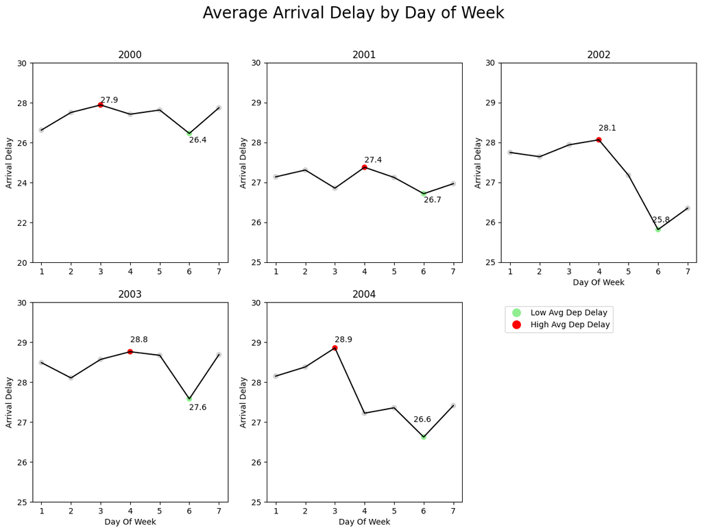

```python
fig, ax = plt.subplots(2,3,figsize= (15,10))#to create 2 rows, 3 columns
fig.suptitle("Average Arrival Delay by Day of Week", fontsize= 20) #plot the title in the middle as main title
sns.lineplot(x= delays_per_day[delays_per_day['Year']== '2000-01-01']["DayOfWeek"],y= delays_per_day[delays_per_day['Year']== '2000-01-01']['Avg_delay'], ax=ax[0][0], color="black")
#create line graph, where the data is from delays_dep_per_day when the year is 2000 ('2000-01-01'). The x is from dayofweek, while the y axis is from Avg_delay (Average_delay) , it is will be shown at row 0 col 0 (first row and first column)
ax[0][0].set_ylim(20,30)#set the y limit into 45 to 59 so that it standardize across all figures
ax[0][0].set_ylabel("Arrival Delay") #set y axis and name it as Arrival Delay
ax[0][0].set_title("2000")
ax[0][0].scatter(delays_per_day[delays_per_day['Year']== '2000-01-01']["DayOfWeek"],delays_per_day[delays_per_day['Year']== '2000-01-01']['Avg_delay'], c =colours_cus_3[0])
#is to plot the point (scatter plot) using the data from delays_per_day when the year is 2000 ('2000-01-01'). The x is from dayofweek, while the y axis is from Avg_delay , the colour of the point will follow the colours_cus_3 and using the index =0 (first list)
ax[0][0].text(6,26, round(mini_3[0],1))#plot the label is mini_3 when index is 0
ax[0][0].text(3,28, round(maxi_3[0],1))#plot the label is maxi_3 when index is 0
ax[0][0].set_xlabel("")

#it will be repeated into subsequent year. However the index of ax will be adjusted since it represent rows and col, e.g [0][1] which is first row and second col, bcs index 0 is first row, index 1 after [0] is second column.
sns.lineplot(x= delays_per_day[delays_per_day['Year']== '2001-01-01']["DayOfWeek"],y= delays_per_day[delays_per_day['Year']== '2001-01-01']['Avg_delay'], ax=ax[0][1], color="black")
ax[0][1].set_ylim(25,30)
ax[0][1].set_ylabel("Arrival Delay")
ax[0][1].set_title("2001")
ax[0][1].scatter(delays_per_day[delays_per_day['Year']== '2001-01-01']["DayOfWeek"],delays_per_day[delays_per_day['Year']== '2001-01-01']['Avg_delay'], c =colours_cus_3[1])
ax[0][1].text(6,26.5, round(mini_3[1],1))
ax[0][1].text(4,27.5, round(maxi_3[1],1))
ax[0][1].set_xlabel("")
#it will be repeated into subsequent year. However the index of ax will be adjusted since it represent rows and col
sns.lineplot(x= delays_per_day[delays_per_day['Year']== '2002-01-01']["DayOfWeek"],y= delays_per_day[delays_per_day['Year']== '2002-01-01']['Avg_delay'], ax=ax[0][2], color="black")
ax[0][2].set_ylim(25,30)
ax[0][2].set_xlabel("Day Of Week")
ax[0][2].set_ylabel("Arrival Delay")
ax[0][2].set_title("2002")
ax[0][2].scatter(delays_per_day[delays_per_day['Year']== '2002-01-01']["DayOfWeek"],delays_per_day[delays_per_day['Year']== '2002-01-01']['Avg_delay'], c =colours_cus_3[2])
ax[0][2].text(5.8,26, round(mini_3[2],1))
ax[0][2].text(4,28.3, round(maxi_3[2],1))

#it will be repeated into subsequent year. However the index of ax will be adjusted since it represent rows and col
sns.lineplot(x= delays_per_day[delays_per_day['Year']== '2003-01-01']["DayOfWeek"],y= delays_per_day[delays_per_day['Year']== '2003-01-01']['Avg_delay'], ax=ax[1][0], color="black")
ax[1][0].set_ylim(25,30)
ax[1][0].set_xlabel("Day Of Week")
ax[1][0].set_ylabel("Arrival Delay")
ax[1][0].set_title("2003")
ax[1][0].scatter(delays_per_day[delays_per_day['Year']== '2003-01-01']["DayOfWeek"],delays_per_day[delays_per_day['Year']== '2003-01-01']['Avg_delay'], c =colours_cus_3[3])
ax[1][0].text(4,29, round(maxi_3[3],1))
ax[1][0].text(6,27.3, round(mini_3[3],1))

#it will be repeated into subsequent year. However the index of ax will be adjusted since it represent rows and col
sns.lineplot(x= delays_per_day[delays_per_day['Year']== '2004-01-01']["DayOfWeek"],y= delays_per_day[delays_per_day['Year']== '2004-01-01']['Avg_delay'], ax=ax[1][1], color="black")
ax[1][1].set_ylim(25,30)
ax[1][1].set_xlabel("Day Of Week")
ax[1][1].set_ylabel("Arrival Delay")
ax[1][1].set_title("2004")
ax[1][1].scatter(delays_per_day[delays_per_day['Year']== '2004-01-01']["DayOfWeek"],delays_per_day[delays_per_day['Year']== '2004-01-01']['Avg_delay'], c =colours_cus_3[4])
ax[1][1].text(3,29, round(maxi_3[4],1))
ax[1][1].text(5.65,27, round(mini_3[4],1))

ax[1][2].axis('off') #as we only have 5 years data, then we only need 5 figure to plots, then the row 2 (index 1) column 3 (index 2) is not shown.

#to create a circle that will be used for legend, where the horizontal line on the circle will be set into white , the color will be light green if it's low ratio delay, while it will be red if it's high ratio delay
#the marker will looks like circle, then the color will be white so the line on the circle is not shown, then it will label as Low and High avg delay, markersize is to set the size into 12 of that circle.
leg_2 = [Line2D ([0],[0], marker='o', color='w', markerfacecolor ='lightgreen', label = "Low Avg Dep Delay", markersize= 12),
        Line2D ([0],[0], marker='o', color='w', markerfacecolor ='red', label= "High Avg Dep Delay", markersize =12)]

#plot the legend using the legends created before, and it located at upper left
plt.legend(handles = leg_2, loc ="upper left")
plt.show()
```

ratio_delay_dof_arrs use datas dataframe and show the flight that is not cancelled and not diverted. Then it will create a new column call Total_Arr_Delay which contains binary number, 1 represents the departure delay is more or equals to 15, otherwise 0. (If the arrival delay is equal or more than 15 and departure delay less than 15 minutes, then it will denoted as 1, otherwise it will be 0. This mean the ratio of delay here will only account for the arrival delay that is not caused by departure delay and avoiding double counting)

ratio_delay_dof_arr will contains ratio_delay_dof_arrs, then it will group by Year and DayOfWees. Then, the total number of delay (Delay_flight), total number of delayed flight (Total_flight) will be calculated. It then creates a new column call Ratio_of_delay, which calculate the ratio of delay (total of delayed flight/ total flight) which is rounded into 1 decimal point and it’s in percenta formatm.

```python
ratio_delay_dof_arrs = data[(data['Cancelled']==0) & (data['Diverted'] ==0)] #it only take data that is contains flight that not cancelled and not diverted
```

```python
ratio_delay_dof_arrs['Total_Arr_Delay'] = np.where((ratio_delay_dof_arrs['ArrDelay']>=15) & (ratio_delay_dof_arrs['DepDelay']<15),1,0) # it use ratio_delay_dof_arrs data, when the DepDelay column have value less than 15 and the ArrDelay must be atleast 15 minutes then in Total_Arr_Delay it stored as 1 otherwise 0.
```

```python
ratio_delay_dof_arrs.head()
```

|  | Year | Month | DayofMonth | DayOfWeek | DepTime | CRSDepTime | ArrTime | CRSArrTime | UniqueCarrier | FlightNum | ... | TaxiOut | Cancelled | CancellationCode | Diverted | CarrierDelay | WeatherDelay | NASDelay | SecurityDelay | LateAircraftDelay | Total_Arr_Delay |
| --- | --- | --- | --- | --- | --- | --- | --- | --- | --- | --- | --- | --- | --- | --- | --- | --- | --- | --- | --- | --- | --- |
| 0 | 2000 | 1 | 28 | 5 | 1647.0 | 1647 | 1906.0 | 1859 | HP | 154 | ... | 11 | 0 | NaN | 0 | NaN | NaN | NaN | NaN | NaN | 0 |
| 1 | 2000 | 1 | 29 | 6 | 1648.0 | 1647 | 1939.0 | 1859 | HP | 154 | ... | 47 | 0 | NaN | 0 | NaN | NaN | NaN | NaN | NaN | 1 |
| 3 | 2000 | 1 | 31 | 1 | 1645.0 | 1647 | 1852.0 | 1859 | HP | 154 | ... | 14 | 0 | NaN | 0 | NaN | NaN | NaN | NaN | NaN | 0 |
| 4 | 2000 | 1 | 1 | 6 | 842.0 | 846 | 1057.0 | 1101 | HP | 609 | ... | 8 | 0 | NaN | 0 | NaN | NaN | NaN | NaN | NaN | 0 |
| 5 | 2000 | 1 | 2 | 7 | 849.0 | 846 | 1148.0 | 1101 | HP | 609 | ... | 24 | 0 | NaN | 0 | NaN | NaN | NaN | NaN | NaN | 1 |

5 rows × 30 columns

```python
ratio_delay_dof_arr = (ratio_delay_dof_arrs.groupby(["Year", "DayOfWeek"]).agg(
    Delay_flight = ('Total_Arr_Delay', 'sum'),
    Total_flight = ('Total_Arr_Delay','count')).reset_index())
#This is group the ratio_delay_dof_arrs by Year and DayOfWeek, where the Delay_flight is the sum of Total_Arr_Delay, while Total_flight is the count of Total_Arr_delay which represents the frequency
```

```python
ratio_delay_dof_arr['Ratio_of_delay'] = round(ratio_delay_dof_arr['Delay_flight'] *100/ratio_delay_dof_arr['Total_flight'],1)
#it will create a new column call Ratio_of_delay inside ratio_delay_dof_arr dataframe
#it's calculated with ratio_delay_dof_arr data, where the Delay_flight is divided by Total_flight and times 100 so that it could be shown in percentage format
#then it will be rounded into one decimal point
```

```python
colours_cus_4 =[]#create empty list
maxi_4=[]#create empty list
mini_4=[]#create empty list
#for y that is from 2000 to 2004,
# the "maxim_4" will contains the row index which contains the maximum of Ratio_of_delay by using ratio_delay_dof_arr data when the year is equal to y
# the "minim_4" will contains the row index which contains the minimum of Ratio_of_delay by using ratio_delay_dof_arr data when the year is equal to y
#custom_colour_4 => when the x is equal to maxim_4 (maximum index of row) it will be denoted as 'red',
#                => when the x is equal to minim_4 (minimum index of row) it will be denoted as 'green'
#                => otherwise it will denoted as 'gray'
# x is inside the index from the ratio_delay_dof_arr when the year is equals to y
#then the custom_colour_4 that have been created before will be stored in colours_cus_4
#ma_4 is using the ratio_delay_dof_arr data and to locate the maxim_4 (maximum index of row) and it will return the Ratio_of_delay on that row index
#mi_4 is using the ratio_delay_dof_arr data and to locate the minim_4 (minimum index of row) and it will return the Ratio_of_delay on that row index
#ma_4 will be stored in maxi_4, while mi_4 will be stored in mini_4

for y in range (2000,2005):
    maxim_4= ratio_delay_dof_arr[ratio_delay_dof_arr['Year']==y]['Ratio_of_delay'].idxmax()
    minim_4= ratio_delay_dof_arr[ratio_delay_dof_arr['Year']==y]['Ratio_of_delay'].idxmin()
    custom_colour_4 = ['red' if x == maxim_4 else 'green' if x==minim_4 else 'gray' for x in (ratio_delay_dof_arr[ratio_delay_dof_arr["Year"]== y]).index]
    colours_cus_4.append(custom_colour_4)
    ma_4 = ratio_delay_dof_arr.loc[maxim_4,'Ratio_of_delay']
    mi_4 = ratio_delay_dof_arr.loc[minim_4,'Ratio_of_delay']
    maxi_4.append(ma_4)
    mini_4.append(mi_4)
```

This will visualise the ratio of arrival delay in each day, by year. It will highlight the highest and lowest ratio with red and green colour respectively. It will show label near the bar chart only if it’s the highest or the lowest ratio.

Frequency of delay isn’t a good measure. High frequency of delays just shows that delay is happen frequently on that day, which ignores the total number of flights. High frequency of delay might occur due to high number of flights and vice versa. Therefore, ratio must be calculated and be shown.

[figure not shown]

```python
fig, ax = plt.subplots(2,3, figsize= (10,6)) #2 rows, 3 columns
ax= ax.flatten() #without this to access the axes is need [0][0] but after using this .flatten() it will allow us to use [0]
plt.suptitle ('Arrival Delay Ratio (%) by Day of Week in 2000 - 2004', fontsize=15) #plot the title in the middle
sns.barplot(data=ratio_delay_dof_arr [ratio_delay_dof_arr["Year"]== 2000], x="DayOfWeek", y="Ratio_of_delay", ax= ax[0],hue='DayOfWeek', palette=colours_cus_4[0], legend=False)
#plot the barplot with the ratio_delay_dof data when the Year is in 2000, with DayOfWeek as x axis, Ratio_of_delay as Y axis, and it will be coloured based on DayOfWeek.
#It then using the colour_cus[0], that contains the list of colour whether it's gray, red, or green. It will take the first list (index 0) of the colour_cus. Then the legend won't be shown as it will cover up the graph
ax[0].set_ylim(0,10) #it will set the y limit from 0 to 28 so that across the figures, it will be standardized
ax[0].set_xlabel('')
ax[0].set_ylabel('Ratio of Delay')
ax[0].text(4.5,6.5, f"{mini_4[0]}%") #it will make a label on the top of bar chart, which is the minimum of the ratio_of_delay values that is stored in mini (when index = 0) then it will be written with %.
ax[0].text(2.5,8.7, f"{maxi_4[0]}%")#it will make a label on the top of bar chart, which is the maximum of the ratio_of_delay values that is stored in maxi (when index = 0) then it will be written with %.

#it will repeat the previous process and adjusted based on certain Year, and the color change based on adjusted colours_cus_4 on each index, while legend set to false mean it won't show the legend on each graphs
sns.barplot(data=ratio_delay_dof_arr [ratio_delay_dof_arr["Year"]== 2001], x="DayOfWeek", y="Ratio_of_delay", ax= ax[1], color="red",hue='DayOfWeek', palette=colours_cus_4[1],legend=False)
ax[1].set_ylim(0,10)
ax[1].set_xlabel('')
ax[1].set_ylabel('')
ax[1].text(4.5,5.5, f"{mini_4[1]}%")
ax[1].text(2.5,7.5, f"{maxi_4[1]}%")
sns.barplot(data=ratio_delay_dof_arr [ratio_delay_dof_arr["Year"]== 2002], x="DayOfWeek", y="Ratio_of_delay", ax= ax[2], color="green", hue='DayOfWeek', palette=colours_cus_4[2],legend=False)
ax[2].set_ylim(0,10)
ax[2].set_xlabel('Day of Week')
ax[2].set_ylabel('')
ax[2].text(2.5,6.8, f"{maxi_4[2]}%")
ax[2].text(4.5,4.8, f"{mini_4[2]}%")
sns.barplot(data=ratio_delay_dof_arr [ratio_delay_dof_arr["Year"]== 2002], x="DayOfWeek", y="Ratio_of_delay", ax= ax[3], color="yellow",hue='DayOfWeek', palette=colours_cus_4[3],legend=False)
ax[3].set_ylim(0,10)
ax[3].set_xlabel('Day of Week')
ax[3].set_ylabel('Ratio of Delay')
ax[3].text(4.5,4.8, f"{mini_4[3]}%")
ax[3].text(2.5,7, f"{maxi_4[3]}%")
sns.barplot(data=ratio_delay_dof_arr [ratio_delay_dof_arr["Year"]== 2002], x="DayOfWeek", y="Ratio_of_delay", ax= ax[4], color="black",hue='DayOfWeek', palette=colours_cus_4[4],legend=False)
ax[4].set_ylim(0,10)
ax[4].set_xlabel('Day of Week')
ax[4].set_ylabel('')
ax[4].text(4.5,5, f"{mini_4[4]}%")
ax[4].text(3.6,6.8, f"{maxi_4[4]}%")
ax[4].text(2.5,6.8, f"{maxi_4[4]}%")
ax[4].text(1.4,6.5, f"{maxi_4[4]}%")
ax[5].axis('off')

leg_notes = [Patch(facecolor = "green", edgecolor ="white", label="Low Dep Delay Ratio"),
            Patch(facecolor = "red", edgecolor= "white", label ="High Dep Delay Ratio")]
#this is to create manually the legend, where the color will be green and red to represents the Low Dep Delay Ratio and High Dep Delay Ratio respectively.
plt.legend(handles = leg_notes, loc = "center") #the legend will be plotted using the leg_notes, that is located in the center
plt.show()
```

Saturday ratio is much lower than Friday. The highest differences between Friday and Saturday ratio reaches 8%. In Friday, the ratio of departure delay is the highest across 5 years. Even though the average delay is not the highest in Friday for all years, delay happens more frequent than other days.

## To answer part 2 a on best times of the day:

To answer which is the best time question, it will select several columns needed, and filter out the cancelled & diverted flight. As theCRS DepTime is in int, then it will be converted into several category, where each category contains 4 hours. There will be 6 category created that represents 24 hours

```python
besttime = data[(data['Cancelled']==0) & (data['Diverted'] == 0)]#it will contain only data that is not cancelled and not diverted
```

```python
besttime['Time'] = besttime['Diverted'].copy() #the Time column will copy the Diverted column
besttime.head() #show the top 5 rows
```

|  | Year | Month | DayofMonth | DayOfWeek | DepTime | CRSDepTime | ArrTime | CRSArrTime | UniqueCarrier | FlightNum | ... | TaxiOut | Cancelled | CancellationCode | Diverted | CarrierDelay | WeatherDelay | NASDelay | SecurityDelay | LateAircraftDelay | Time |
| --- | --- | --- | --- | --- | --- | --- | --- | --- | --- | --- | --- | --- | --- | --- | --- | --- | --- | --- | --- | --- | --- |
| 0 | 2000 | 1 | 28 | 5 | 1647.0 | 1647 | 1906.0 | 1859 | HP | 154 | ... | 11 | 0 | NaN | 0 | NaN | NaN | NaN | NaN | NaN | 0 |
| 1 | 2000 | 1 | 29 | 6 | 1648.0 | 1647 | 1939.0 | 1859 | HP | 154 | ... | 47 | 0 | NaN | 0 | NaN | NaN | NaN | NaN | NaN | 0 |
| 3 | 2000 | 1 | 31 | 1 | 1645.0 | 1647 | 1852.0 | 1859 | HP | 154 | ... | 14 | 0 | NaN | 0 | NaN | NaN | NaN | NaN | NaN | 0 |
| 4 | 2000 | 1 | 1 | 6 | 842.0 | 846 | 1057.0 | 1101 | HP | 609 | ... | 8 | 0 | NaN | 0 | NaN | NaN | NaN | NaN | NaN | 0 |
| 5 | 2000 | 1 | 2 | 7 | 849.0 | 846 | 1148.0 | 1101 | HP | 609 | ... | 24 | 0 | NaN | 0 | NaN | NaN | NaN | NaN | NaN | 0 |

5 rows × 30 columns

```python
besttime.loc[(besttime['CRSDepTime'] >=0 ) & (besttime ['CRSDepTime'] <=400),'Time'] = "0-4"
besttime.loc[(besttime['CRSDepTime'] >400 ) & (besttime ['CRSDepTime'] <=800),'Time'] = "4-8"
besttime.loc[(besttime['CRSDepTime'] >800 ) & (besttime ['CRSDepTime'] <=1200),'Time'] = "8-12"
besttime.loc[(besttime['CRSDepTime'] >1200 ) & (besttime ['CRSDepTime'] <=1600),'Time'] = "12-16"
besttime.loc[(besttime['CRSDepTime'] >1600 ) & (besttime ['CRSDepTime'] <=2000),'Time'] = "16-20"
besttime.loc[(besttime['CRSDepTime'] >2000 ) & (besttime ['CRSDepTime'] <=2400),'Time'] = "20-24"

#It will use besttime data
#1. select the rows that satisfy the conditions, which is when the CRSDepTime is more or equals to 0 and less or equals to 400, then change the 'Time' into "0-4"
#2. select the rows that satisfy the conditions, which is when the CRSDepTime is more than 400 and less or equals to 800, then change the 'Time' into "4-8"
#3. select the rows that satisfy the conditions, which is when the CRSDepTime is more than to 800 and less or equals to 1200, then change the 'Time' into "8-12"
#4. select the rows that satisfy the conditions, which is when the CRSDepTime is more than to 1200 and less or equals to 1600, then change the 'Time' into "12-16"
#5. select the rows that satisfy the conditions, which is when the CRSDepTime is more than to 1600 and less or equals to 2000, then change the 'Time' into "16-20"
#5. select the rows that satisfy the conditions, which is when the CRSDepTime is more than to 2000 and less or equals to 2000, then change the 'Time' into "20-24"

besttime.head() #show the top 5 rows
```

|  | Year | Month | DayofMonth | DayOfWeek | DepTime | CRSDepTime | ArrTime | CRSArrTime | UniqueCarrier | FlightNum | ... | TaxiOut | Cancelled | CancellationCode | Diverted | CarrierDelay | WeatherDelay | NASDelay | SecurityDelay | LateAircraftDelay | Time |
| --- | --- | --- | --- | --- | --- | --- | --- | --- | --- | --- | --- | --- | --- | --- | --- | --- | --- | --- | --- | --- | --- |
| 0 | 2000 | 1 | 28 | 5 | 1647.0 | 1647 | 1906.0 | 1859 | HP | 154 | ... | 11 | 0 | NaN | 0 | NaN | NaN | NaN | NaN | NaN | 16-20 |
| 1 | 2000 | 1 | 29 | 6 | 1648.0 | 1647 | 1939.0 | 1859 | HP | 154 | ... | 47 | 0 | NaN | 0 | NaN | NaN | NaN | NaN | NaN | 16-20 |
| 3 | 2000 | 1 | 31 | 1 | 1645.0 | 1647 | 1852.0 | 1859 | HP | 154 | ... | 14 | 0 | NaN | 0 | NaN | NaN | NaN | NaN | NaN | 16-20 |
| 4 | 2000 | 1 | 1 | 6 | 842.0 | 846 | 1057.0 | 1101 | HP | 609 | ... | 8 | 0 | NaN | 0 | NaN | NaN | NaN | NaN | NaN | 8-12 |
| 5 | 2000 | 1 | 2 | 7 | 849.0 | 846 | 1148.0 | 1101 | HP | 609 | ... | 24 | 0 | NaN | 0 | NaN | NaN | NaN | NaN | NaN | 8-12 |

5 rows × 30 columns

“arrival_del” is using besttime dataframe and contains only arrival delay which is not caused by DepDelay.

```python
arrival_del = besttime [(besttime['ArrDelay'] >= 15) & (besttime['DepDelay'] < 15)] #it's contain Arrival Delay only that is more than or equals to 15, and the DepDelay is less than 15, means the arrival delay is not departure delay
```

1. The data will be grouped based on Year, Time, and DayOfWeek and calculate the total arrival delay, average arrival delay, and frequency of arrival delay.

Then it will show boxplot by time category with the average arrival delay. It’s shown by yearr.

```python
timing_1 = (arrival_del.groupby(['Year', 'Time', 'DayOfWeek']).agg(
    Total_delay = ('ArrDelay', 'sum'),
    Avg_delay = ('ArrDelay','mean'),
    Count_delay = ('ArrDelay','count')).reset_index())

#the timing_1 contains the arrival_del and group it by Year, Time, and DayOfWeek, so that it will calculate the Total_delay by sum of ArrDelay
#Avg_delay calculated by average of ArrDelay, and Count_delay is by count the frequency of it.
#it also reset_index so will make viz easier
```

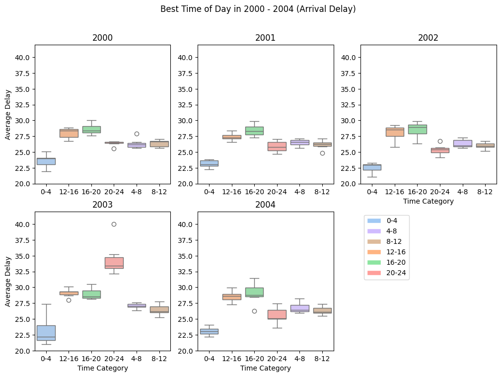

```python
fig, ax = plt.subplots(2,3, figsize= (12,8))
ax= ax.flatten()#so it's easier to plot , since it make into 1d
sns.boxplot(data= timing_1[timing_1['Year']==2000], x="Time",y= "Avg_delay", ax=ax[0], hue= "Time", palette="pastel")#it will divide the color based on Time
ax[0].set_xlabel("")
ax[0].set_ylabel("Average Delay")
ax[0].set_title("2000")
ax[0].set_ylim(20,42)
sns.boxplot(data= timing_1[timing_1['Year']==2001], x="Time",y= "Avg_delay", ax=ax[1],hue= "Time", palette="pastel")
ax[1].set_xlabel("")
ax[1].set_ylabel("")
ax[1].set_title("2001")
ax[1].set_ylim(20,42)
sns.boxplot(data= timing_1[timing_1['Year']==2002], x="Time",y= "Avg_delay", ax=ax[2],hue= "Time", palette="pastel")
ax[2].set_ylabel("")
ax[2].set_xlabel("Time Category")
ax[2].set_title("2002")
ax[2].set_ylim(20,42)
sns.boxplot(data= timing_1[timing_1['Year']==2003], x="Time",y= "Avg_delay", ax=ax[3],hue= "Time", palette="pastel")
ax[3].set_ylabel("Average Delay")
ax[3].set_xlabel("Time Category")
ax[3].set_title("2003")
ax[3].set_ylim(20,42)
sns.boxplot(data= timing_1[timing_1['Year']==2004], x="Time",y= "Avg_delay", ax=ax[4],hue= "Time", palette="pastel")
ax[4].set_ylabel("")
ax[4].set_xlabel("Time Category")
ax[4].set_title("2004")
ax[4].set_ylim(20,42)
ax[5].axis('off')
plt.suptitle ("Best Time of Day in 2000 - 2004 (Arrival Delay)")

palette_pastel = sns.color_palette("pastel",n_colors= 6) #to get the colour used from the palette call pastel, here we use 6 colours
leg_notes_2 = [Patch(facecolor = palette_pastel[0], edgecolor ="white", label="0-4"),
            Patch(facecolor = palette_pastel[4], edgecolor= "white", label ="4-8"),
            Patch(facecolor = palette_pastel[5], edgecolor= "white", label ="8-12"),
            Patch(facecolor = palette_pastel[1], edgecolor= "white", label ="12-16"),
            Patch(facecolor = palette_pastel[2], edgecolor= "white", label ="16-20"),
            Patch(facecolor = palette_pastel[3], edgecolor= "white", label ="20-24")]
#this is to create manually the legend, where the color will be the palette "pastel" to represents the time category respectively.

plt.legend(handles = leg_notes_2, loc = "upper left") #the legend will be plotted using the leg_notes_2, that is located in the top right
plt.show()
```

It seems when 00:00 to 04:00 average delay is the lowest across the year.

As low arrival delay doesn’t mean it’s good enough, the fact we need to see on the ratio of arrival delay, to see the likelihood of delay happening. In addition, frequency is not a good measure to calculate how bad the delay is (have been explained above).

arr_ratio_time will used the ratio_delay_dof_arrs data (previously created), that filter out one NA value on Total_Arr_Delay (only one NA), which is unlikely to impact on the overall result. Then it will categorise the scheduled departure time into 6 categories. Then it will be grouped by year, day of week, and time category with summarise value to calculate the ratio of delay. The calculation is the same as before (delayed flight /total flight, in a percentage format, with one decimal point).

```python
ratio_delay_dof_arrs ['Time'] = ratio_delay_dof_arrs['Total_Arr_Delay'].copy()
ratio_delay_dof_arrs.loc[(ratio_delay_dof_arrs['CRSDepTime'] >=0 ) & (ratio_delay_dof_arrs ['CRSDepTime'] <=400),'Time'] = "0-4"
ratio_delay_dof_arrs.loc[(ratio_delay_dof_arrs['CRSDepTime'] >400 ) & (ratio_delay_dof_arrs ['CRSDepTime'] <=800),'Time'] = "4-8"
ratio_delay_dof_arrs.loc[(ratio_delay_dof_arrs['CRSDepTime'] >800 ) & (ratio_delay_dof_arrs ['CRSDepTime'] <=1200),'Time'] = "8-12"
ratio_delay_dof_arrs.loc[(ratio_delay_dof_arrs['CRSDepTime'] >1200 ) & (ratio_delay_dof_arrs ['CRSDepTime'] <=1600),'Time'] = "12-16"
ratio_delay_dof_arrs.loc[(ratio_delay_dof_arrs['CRSDepTime'] >1600 ) & (ratio_delay_dof_arrs ['CRSDepTime'] <=2000),'Time'] = "16-20"
ratio_delay_dof_arrs.loc[(ratio_delay_dof_arrs['CRSDepTime'] >2000 ) & (ratio_delay_dof_arrs ['CRSDepTime'] <=2400),'Time'] = "20-24"
```

```python
arr_ratio_time = (ratio_delay_dof_arrs.groupby(['Year','DayOfWeek','Time']).agg(
    Delay_flight = ("Total_Arr_Delay", "sum"),
    Total_flight = ("Total_Arr_Delay", "count")).reset_index())#reset index so it easier for viz
```

```python
arr_ratio_time['Ratio_of_delay']= round(arr_ratio_time['Delay_flight'] *100 / arr_ratio_time['Total_flight'],1)#calculation of ratio of delay
```

```python
arr_ratio_time.head()
```

|  | Year | DayOfWeek | Time | Delay_flight | Total_flight | Ratio_of_delay |
| --- | --- | --- | --- | --- | --- | --- |
| 0 | 2000 | 1 | 0-4 | 286 | 4644 | 6.2 |
| 1 | 2000 | 1 | 12-16 | 13308 | 192741 | 6.9 |
| 2 | 2000 | 1 | 16-20 | 13365 | 189853 | 7.0 |
| 3 | 2000 | 1 | 20-24 | 5297 | 88265 | 6.0 |
| 4 | 2000 | 1 | 4-8 | 8749 | 123244 | 7.1 |

```python
#convert it into pivot, where the index is Year and DayOfWeek, the columns become the Time which is the time category, with Ratio_of_delay as the value
arr_ratio_time_heat = arr_ratio_time.pivot(index= ["Year","DayOfWeek"],columns= "Time", values= "Ratio_of_delay")
```

```python
arr_ratio_time_heat_2000 = arr_ratio_time_heat.head(7)#take only row which is on the tops 7 rows
arr_ratio_time_heat_2000
```

| Year | Time DayOfWeek | 0-4 | 12-16 | 16-20 | 20-24 | 4-8 | 8-12 |
| --- | --- | --- | --- | --- | --- | --- | --- |
| 2000 | 1 | 6.2 | 6.9 | 7.0 | 6.0 | 7.1 | 7.4 |
|  | 2 | 6.1 | 6.9 | 7.4 | 5.9 | 7.3 | 7.4 |
|  | 3 | 5.5 | 7.7 | 8.0 | 6.4 | 7.3 | 7.6 |
|  | 4 | 5.7 | 8.0 | 8.6 | 7.1 | 8.1 | 8.2 |
|  | 5 | 6.9 | 8.4 | 7.9 | 6.4 | 8.0 | 8.5 |
|  | 6 | 5.9 | 5.7 | 4.9 | 4.4 | 6.0 | 6.5 |
|  | 7 | 5.5 | 7.9 | 7.5 | 6.2 | 5.3 | 7.1 |

```python
#based on the index, it will divide it per year, to make viz easier.
arr_ratio_time_heat_2001 = arr_ratio_time_heat.iloc[7:14]#take the rows or values when the index is 7 to 13
arr_ratio_time_heat_2002 = arr_ratio_time_heat.iloc[14:21]# when the index is 14 to 20
arr_ratio_time_heat_2003 = arr_ratio_time_heat.iloc[21:28]#when the index is 21 to 27
arr_ratio_time_heat_2004 = arr_ratio_time_heat.iloc[28:35]#when the index is 27 to 34
```

The ratio of delay is displayed by heatmap in each year from 2000 to 2004. It will shows the ratio of delay based on day of week from Mon to Sun and Time category. When the ratio of delay is low, it will be light green, and if it’s high ratio it will be in dark green.

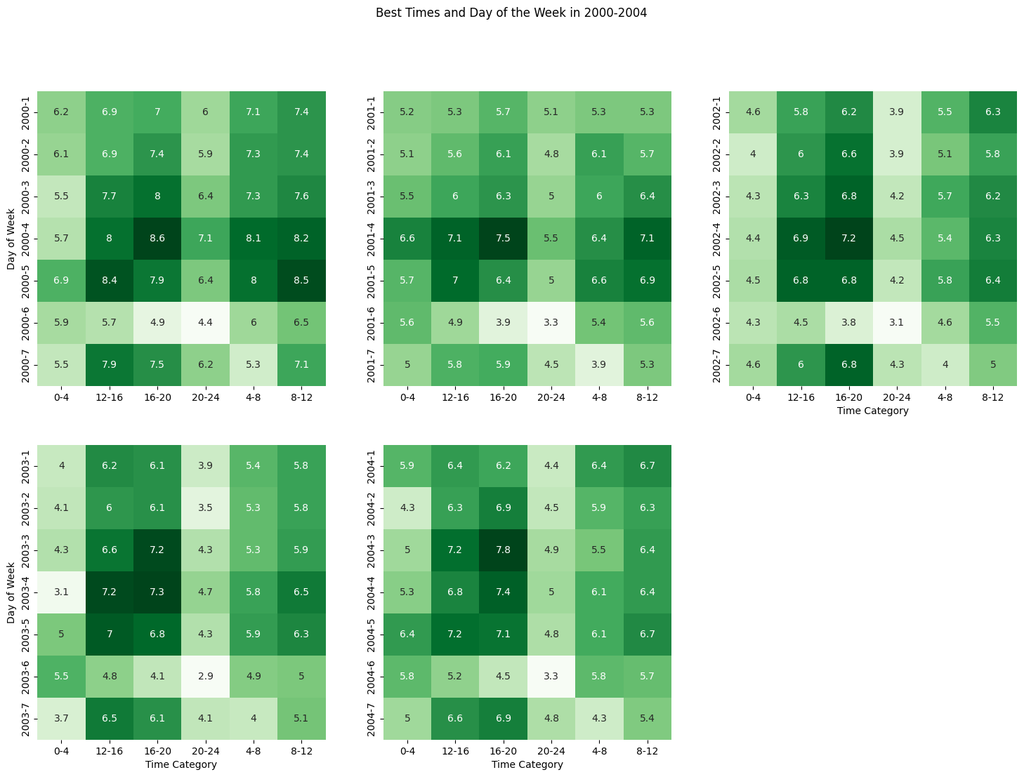

```python
fig, ax = plt.subplots(2,3, figsize= (18,12))
ax = ax.flatten()
sns.heatmap(data=arr_ratio_time_heat_2000, annot=True, cmap='Greens',cbar= False, ax=ax[0])
ax[0].set_ylabel("Day of Week")
ax[0].set_xlabel("")
sns.heatmap(data=arr_ratio_time_heat_2001, annot=True, cmap='Greens',cbar= False, ax=ax[1])
ax[1].set_ylabel("")
ax[1].set_xlabel("")
sns.heatmap(data=arr_ratio_time_heat_2002, annot=True, cmap='Greens',cbar= False, ax=ax[2])
ax[2].set_ylabel("")
ax[2].set_xlabel("Time Category")
sns.heatmap(data=arr_ratio_time_heat_2003, annot=True, cmap='Greens',cbar= False, ax=ax[3])
ax[3].set_ylabel("Day of Week")
ax[3].set_xlabel("Time Category")
sns.heatmap(data=arr_ratio_time_heat_2004, annot=True, cmap='Greens', cbar= False,ax=ax[4])
ax[4].set_ylabel("")
ax[4].set_xlabel("Time Category")
plt.suptitle("Best Times and Day of the Week in 2000-2004")
ax[5].axis('off')
plt.show()
```

“depart_del” is using besttime dataframe (previously created) and contains only departure delay (DepDelay >=15). Since it’s based on definition provided by OAG.

```python
depart_del = besttime [besttime['DepDelay']>=15]
```

This steps will repeat on the arrival delay that have been done before. The only difference is only on the data used, where here we use departure delay (depart_del).

```python
timing_3 = (depart_del.groupby(['Year','Time','DayOfWeek']).agg(
    Total_delay = ('DepDelay','sum'),
    Avg_delay = ('DepDelay', 'mean'),
    Count_delay= ('DepDelay', 'count')).reset_index())
```

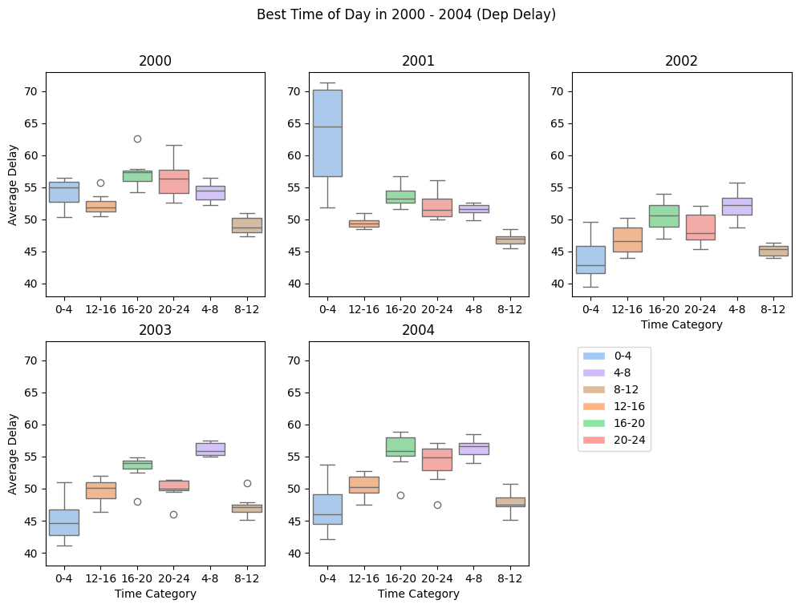

```python
fig, ax = plt.subplots(2,3, figsize= (12,8))
ax= ax.flatten()
sns.boxplot(data= timing_3[timing_3['Year']==2000], x="Time",y= "Avg_delay", ax=ax[0], hue= "Time", palette="pastel")
ax[0].set_xlabel("")
ax[0].set_ylabel("Average Delay")
ax[0].set_title("2000")
ax[0].set_ylim(38,73)
sns.boxplot(data= timing_3[timing_3['Year']==2001], x="Time",y= "Avg_delay", ax=ax[1],hue= "Time", palette="pastel")
ax[1].set_xlabel("")
ax[1].set_ylabel("")
ax[1].set_title("2001")
ax[1].set_ylim(38,73)
sns.boxplot(data= timing_3[timing_3['Year']==2002], x="Time",y= "Avg_delay", ax=ax[2],hue= "Time", palette="pastel")
ax[2].set_ylabel("")
ax[2].set_xlabel("Time Category")
ax[2].set_title("2002")
ax[2].set_ylim(38,73)
sns.boxplot(data= timing_3[timing_3['Year']==2003], x="Time",y= "Avg_delay", ax=ax[3],hue= "Time", palette="pastel")
ax[3].set_ylabel("Average Delay")
ax[3].set_xlabel("Time Category")
ax[3].set_title("2003")
ax[3].set_ylim(38,73)
sns.boxplot(data= timing_3[timing_3['Year']==2004], x="Time",y= "Avg_delay", ax=ax[4],hue= "Time", palette="pastel")
ax[4].set_ylabel("")
ax[4].set_xlabel("Time Category")
ax[4].set_title("2004")
ax[4].set_ylim(38,73)
ax[5].axis('off')
plt.suptitle ("Best Time of Day in 2000 - 2004 (Dep Delay)")

plt.legend(handles = leg_notes_2, loc = "upper left") #the legend will be plotted using the leg_notes_2, that is located in the top right
plt.show()
```

This process will repeating the arrival delay steps, where ratio of delay being calculated and visualise it using heatmap.

As low departure delay doesn’t mean it’s good enough, the fact we need to see on the ratio of departure delay, to see the likelihood of delay happening. In addition, frequency is not a good measure to calculate how bad the delay is (have been explained above).

dep_ratio_time will used the ratio_delay_dofs data. It will create Time, which is a time category. It will grouped the 24 hours into 6 categories. Then it will categorise the scheduled departure time into 6 categories. Then it will be grouped by year, day of week, and time category with summarise value to calculate the ratio of delay. The calculation is the same as before (delayed flight /total flight, in a percentage format, with one decimal point).

```python
#here it will copy the ratio_delay_dofs when the column is Total_Arr_Delay and copy it into Time column
ratio_delay_dofs ['Time'] = ratio_delay_dofs['Total_Arr_Delay'].copy()
ratio_delay_dofs.loc[(ratio_delay_dofs['CRSDepTime'] >=0 ) & (ratio_delay_dofs ['CRSDepTime'] <=400),'Time'] = "0-4"#when the CRSDepTime is from 0 to 400, then the Time column will be written as "0-4"
ratio_delay_dofs.loc[(ratio_delay_dofs['CRSDepTime'] >400 ) & (ratio_delay_dofs ['CRSDepTime'] <=800),'Time'] = "4-8"#when the CRSDepTime is from 400 to 800, then the Time column will be written as "4-8"
ratio_delay_dofs.loc[(ratio_delay_dofs['CRSDepTime'] >800 ) & (ratio_delay_dofs ['CRSDepTime'] <=1200),'Time'] = "8-12"#when the CRSDepTime is from 800 to 1200, then the Time column will be written as "8-12"
ratio_delay_dofs.loc[(ratio_delay_dofs['CRSDepTime'] >1200 ) & (ratio_delay_dofs ['CRSDepTime'] <=1600),'Time'] = "12-16"#when the CRSDepTime is from 1200 to 1600, then the Time column will be written as "12-16"
ratio_delay_dofs.loc[(ratio_delay_dofs['CRSDepTime'] >1600 ) & (ratio_delay_dofs ['CRSDepTime'] <=2000),'Time'] = "16-20"#when the CRSDepTime is from 1600 to 2000, then the Time column will be written as "16-20"
ratio_delay_dofs.loc[(ratio_delay_dofs['CRSDepTime'] >2000 ) & (ratio_delay_dofs ['CRSDepTime'] <=2400),'Time'] = "20-24"#when the CRSDepTime is from 2000 to 2400, then the Time column will be written as "20-24"
```

```python
dep_ratio_time = (ratio_delay_dofs.groupby(['Year','DayOfWeek','Time']).agg(
    Delay_flight = ("Total_Arr_Delay", "sum"),
    Total_flight = ("Total_Arr_Delay", "count")).reset_index())
#it will group by Year, DayOfWeek, and Time, then it will calculate the Delay_flight and Total_flight by sum the Total_Arr_Delay and count it respectively.
#it will also reset index so the index is being reseted and for visualisation purpose
```

```python
dep_ratio_time['Ratio_of_delay']= round(dep_ratio_time['Delay_flight'] *100 / dep_ratio_time['Total_flight'],1)#it is calculated with round of one decimal point
```

```python
dep_ratio_time_heat = dep_ratio_time.pivot(index= ["Year","DayOfWeek"],columns= "Time", values= "Ratio_of_delay")#it is repeated the arrival delay, here it used the dep_ratio_time and convert it into pivot so it's easier for viz
dep_ratio_time_heat.head()#show the  top five rows
```

| Year | Time DayOfWeek | 0-4 | 12-16 | 16-20 | 20-24 | 4-8 | 8-12 |
| --- | --- | --- | --- | --- | --- | --- | --- |
| 2000 | 1 | 20.7 | 21.1 | 25.5 | 24.0 | 8.2 | 16.1 |
|  | 2 | 14.7 | 17.9 | 23.2 | 21.6 | 6.5 | 13.3 |
|  | 3 | 14.9 | 19.5 | 26.6 | 25.8 | 6.5 | 13.6 |
|  | 4 | 20.3 | 24.7 | 33.5 | 34.2 | 7.8 | 17.2 |
|  | 5 | 23.0 | 28.3 | 37.7 | 36.8 | 8.0 | 17.7 |

```python
dep_ratio_time_heat_2000 = dep_ratio_time_heat.head(7) #stored it as top 7 rows into that dep_ratio_time_heat_2000
dep_ratio_time_heat_2000
```

| Year | Time DayOfWeek | 0-4 | 12-16 | 16-20 | 20-24 | 4-8 | 8-12 |
| --- | --- | --- | --- | --- | --- | --- | --- |
| 2000 | 1 | 20.7 | 21.1 | 25.5 | 24.0 | 8.2 | 16.1 |
|  | 2 | 14.7 | 17.9 | 23.2 | 21.6 | 6.5 | 13.3 |
|  | 3 | 14.9 | 19.5 | 26.6 | 25.8 | 6.5 | 13.6 |
|  | 4 | 20.3 | 24.7 | 33.5 | 34.2 | 7.8 | 17.2 |
|  | 5 | 23.0 | 28.3 | 37.7 | 36.8 | 8.0 | 17.7 |
|  | 6 | 22.2 | 20.9 | 22.5 | 19.9 | 8.8 | 15.8 |
|  | 7 | 19.9 | 22.9 | 33.1 | 33.9 | 7.1 | 13.1 |

```python
dep_ratio_time_heat_2001 = dep_ratio_time_heat.iloc[7:14]#for index 7 to 13 store the rows or values into the dep_ratio_time_heat_2001
dep_ratio_time_heat_2002 = dep_ratio_time_heat.iloc[14:21]#for index 14 to 20 store the rows or values into the dep_ratio_time_heat_2002
dep_ratio_time_heat_2003 = dep_ratio_time_heat.iloc[21:28]#for index 21 to 27 store the rows or values into the dep_ratio_time_heat_2003
dep_ratio_time_heat_2004 = dep_ratio_time_heat.iloc[28:35]#for index 28 to 33 store the rows or values into the dep_ratio_time_heat_2004
```

While 16:00 to 20:00 might be the worst time since it have high average delay as well as high ratio delay.

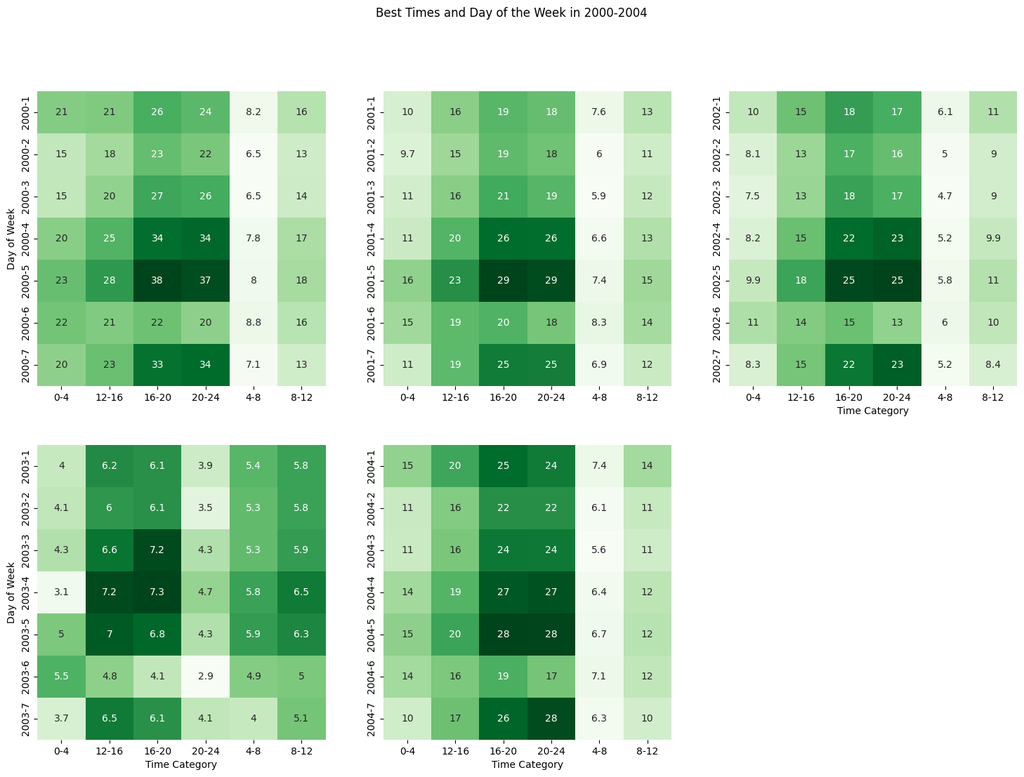

```python
fig, ax = plt.subplots(2,3, figsize= (18,12))
ax = ax.flatten()
sns.heatmap(data=dep_ratio_time_heat_2000, annot=True, cmap='Greens',cbar= False, ax=ax[0])
ax[0].set_ylabel("Day of Week")
ax[0].set_xlabel("")
sns.heatmap(data=dep_ratio_time_heat_2001, annot=True, cmap='Greens',cbar= False, ax=ax[1])
ax[1].set_ylabel("")
ax[1].set_xlabel("")
sns.heatmap(data=dep_ratio_time_heat_2002, annot=True, cmap='Greens',cbar= False, ax=ax[2])
ax[2].set_ylabel("")
ax[2].set_xlabel("Time Category")
sns.heatmap(data=arr_ratio_time_heat_2003, annot=True, cmap='Greens',cbar= False, ax=ax[3])
ax[3].set_ylabel("Day of Week")
ax[3].set_xlabel("Time Category")
sns.heatmap(data=dep_ratio_time_heat_2004, annot=True, cmap='Greens', cbar= False,ax=ax[4])
ax[4].set_ylabel("")
ax[4].set_xlabel("Time Category")
plt.suptitle("Best Times and Day of the Week in 2000-2004")
ax[5].axis('off')
plt.show()
```

While in arrival delay, the ratio of delay is quite similar, with minor differences. The average arrival delay (boxplot) shows that 4-8 indeed have higher average delay than 0-4. But it should be considered that the difference of avg delay is small. Therefore, 0-4 indeed have shorter delay than 4-8 but the delays happen more frequently. While 4-8 may have a bit longer delay than 0-4, but the ratio of delay is much smaller than it. Therefore, 4-8 is more recommended than 0-4.

## To answer 2 b

To answer part b qn, we need plane-data csv. then it will be stored in plane_age variable. Then to standardised the column name, we create a new column call TailNum that will be joined with the datas. It will stored in age_flight by left join the datas data frame with the plane_age. It will filter only the non-cancelled, non-diverted, with arrival delay or departure delay more than 15 .

It will read the plane-data.csv and stored it in plane_age

```python
plane_age = pd.read_csv("plane-data.csv")#read the csv file call plane-data
```

```python
plane_age['TailNum']= plane_age['tailnum']#create a new col call TailNum that contain tailnum
```

```python
datas = data[['Diverted','Year','CRSDepTime',"ArrDelay","DepDelay","CRSDepTime","Cancelled","TailNum"]]#select only certain columns so it's more efficient
```

```python
age_flights = pd.merge(datas, plane_age, on ="TailNum", how ="left")#left join the datas with plane_age on TailNum (the same column that appear on both datasets)
```

```python
age_flight = age_flights[(age_flights['Cancelled']==0) & (age_flights['Diverted']==0)]#filter only the data which is not cancelled and not diverted
```

This will replace the year column, with new “year” column. When the original year is “None” or 0 then it will converted into NA. As year is None mean it’s NA. while the year 0, is unlikely so. As here year represents the manufacturer year, it can’t be 0.

```python
age_flight['year'] = age_flight['year'].replace(0.0,np.nan)
```

```python
age_flight['year']= np.where(age_flight['year'] == "None",np.nan,age_flight['year'])
```

Then It will create “age” column by calculating the difference of flight year with manufactured year.

When the manufacture year is more than the flight year, mean there’s problem in data. It’s impossible to have flight year example, in 2000, but the flight manufactured in 2003.

Here the Na’s value will be here, as it will be used in later purpose

```python
og= age_flight [(age_flight['year'] <= age_flight['Year']) | (age_flight['year'].isna())]
og.shape
```

```
(29757400, 17)
```

```python
og['age'] = og['Year']- og['year']#create age column and it is calculated by Year - year explained above
```

```python
og.shape #to see how many rows and columns there inside og
```

```
(29757400, 18)
```

There’s huge amount of NA. When it’s excluded from analysis, the conclusion must be seen with cautious.

```python
print(og.isna().sum())
```

```
Diverted                0
Year                    0
CRSDepTime              0
ArrDelay                1
DepDelay                0
CRSDepTime              0
Cancelled               0
TailNum                58
tailnum          16373328
type             17464273
manufacturer     17464273
issue_date       17464273
model            17464273
status           17464273
aircraft_type    17464273
engine_type      17479298
year             17676708
age              17676708
dtype: int64
```

```python
depdelays = og[og['DepDelay']>= 15]
#It’s only when departure delay happened (more than 15 minutes delay). We will create category of age, which is useful for visualisation purpose.
```

```python
depdelays['Age_category'] = depdelays['Diverted'].copy()#it will create a new column call  Age_category then it will contain the Diverted column at first, then it will be modified
depdelays.loc[(depdelays['age'] >=0 ) & (depdelays ['age'] <=10),'Age_category'] = "0-10" #when the age is from 0 to 10 it will denoted as 0-10
depdelays.loc[(depdelays['age'] >=11 ) & (depdelays ['age'] <=20),'Age_category'] = "11-20"#when the age is from 11 to 20 it will denoted as 11-20
depdelays.loc[(depdelays['age'] >=21 ) & (depdelays ['age'] <=30),'Age_category'] = "21-30"#when the age is from 21 to 30 it will denoted as 21-30
depdelays.loc[(depdelays['age'] >=31 ) & (depdelays ['age'] <=40),'Age_category'] = "31-40"#when the age is from 31 to 40 it will denoted as 31-40
depdelays.loc[(depdelays['age'] >=41 ) & (depdelays ['age'] <=50),'Age_category'] = "41-50"#when the age is from 41 to 50 it will denoted as 41-50
depdelays.loc[depdelays['age'] ==np.nan,'Age_category'] = np.nan #when the age is na, it will denoted as na
```

```python
print(depdelays.isna().sum())
```

```
Diverted               0
Year                   0
CRSDepTime             0
ArrDelay               0
DepDelay               0
CRSDepTime             0
Cancelled              0
TailNum               12
tailnum          2803061
type             2967121
manufacturer     2967121
issue_date       2967121
model            2967121
status           2967121
aircraft_type    2967121
engine_type      2969287
year             3001874
age              3001874
Age_category           0
dtype: int64
```

```python
depdelays.shape
```

```
(4803256, 19)
```

Here it want to compares how many NA's values in each year

```python
depdelays[depdelays['age'].isna()].groupby('Year')['Year'].count()#To count of how many NA's values each year, by grouping it by Year then count it.
```

```
Year
2000    702515
2001    921293
2002    476974
2003    432865
2004    468227
Name: Year, dtype: int64
```

```python
depdelays.groupby('Year')['Year'].count() # this is including NA values
#we can see in year 2000, out of 1125064 rows, there's 702515 Na values
#we can see in year 2001, out of 949495 rows, there's 921293 Na values
#we can see in year 2002, out of 714479 rows, there's 476974 Na values
#we can see in year 2003, out of 831210 rows, there's 432865 Na values
#we can see in year 2004, out of 1183008 rows, there's 468227 Na values
#there's huge NA's values in 2001 which is almost all of them are NA's
```

```
Year
2000    1125064
2001     949495
2002     714479
2003     831210
2004    1183008
Name: Year, dtype: int64
```

```python
age_dep_delay = (depdelays.groupby(['Year','age','Age_category']).agg(
    DepDelay = ('DepDelay','mean'),
    Num_of_delay = ('DepDelay', 'count')).reset_index())
```

```python
age_dep_delay.tail()#show the lowest 5 or bottom five of the rows
```

|  | Year | age | Age_category | DepDelay | Num_of_delay |
| --- | --- | --- | --- | --- | --- |
| 176 | 2004 | 41.0 | 41-50 | 62.745399 | 326 |
| 177 | 2004 | 42.0 | 41-50 | 65.271845 | 206 |
| 178 | 2004 | 45.0 | 41-50 | 57.168766 | 397 |
| 179 | 2004 | 47.0 | 41-50 | 43.629032 | 124 |
| 180 | 2004 | 48.0 | 41-50 | 56.568182 | 44 |

It will show the scatter plot with linear model (linear regression line) then the color will be adjusted by age category. Then it won’t show the stadard error. It will plot by year. It seems the relationship between age and departure delay is quite weak. However in 2001, the data seems much little than other years, it reinforces previous analysis where the NA’s values belongs more to 2001 data.

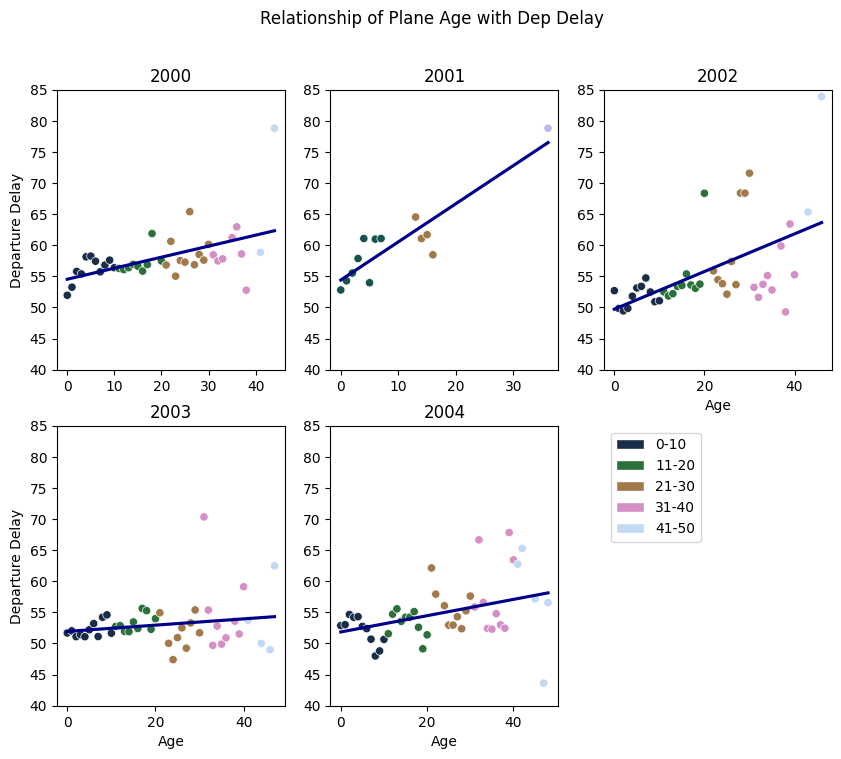

```python
fig, ax = plt.subplots(2,3, figsize= (10,8))
ax= ax.flatten()# convert to 1 dimensional / 1d
sns.scatterplot(data= age_dep_delay[age_dep_delay['Year']==2000], x= 'age',y='DepDelay', hue='Age_category',legend=False,palette="cubehelix",ax=ax[0])#plot at the firt row first column, where the legend won't be shown as it cover the graph. it will coloured based on the Age_category, with age on the x axis, and DepDelay (which here is Average since it has been calculated before) on the y axis
sns.regplot(data= age_dep_delay[age_dep_delay['Year']==2000], x= 'age',y='DepDelay',scatter=False, ci=None, ax=ax[0], color="darkblue")#it plot the regression line, when the data have Year is 2000, it won't plot the scatter, and the confidence interval won't be shown since it set to be None , with dark blue color
ax[0].set_ylim(40,85) #set y limit from 40 to 85 so it will be standardized
ax[0].set_xlabel("")#set the x label
ax[0].set_ylabel("Departure Delay")#set the y label
ax[0].set_title('2000')#let the Year become the title of each graph
#it's repeated from the 2000 data, while here it will continue from 2001 to 2004, and plot it subsequently
sns.scatterplot(data= age_dep_delay[age_dep_delay['Year']==2001], x= 'age',y='DepDelay', hue='Age_category',legend=False,palette="cubehelix",ax=ax[1])
sns.regplot(data= age_dep_delay[age_dep_delay['Year']==2001], x= 'age',y='DepDelay',scatter=False, ci=None, ax=ax[1], color="darkblue")
ax[1].set_ylim(40,85)
ax[1].set_xlabel("")
ax[1].set_ylabel("")
ax[1].set_title('2001')
sns.scatterplot(data= age_dep_delay[age_dep_delay['Year']==2002], x= 'age',y='DepDelay', hue='Age_category',legend=False,palette="cubehelix",ax=ax[2])
sns.regplot(data= age_dep_delay[age_dep_delay['Year']==2002], x= 'age',y='DepDelay',scatter=False, ci=None, ax=ax[2], color="darkblue")
ax[2].set_ylim(40,85)
ax[2].set_xlabel("Age")
ax[2].set_ylabel("")
ax[2].set_title('2002')
sns.scatterplot(data= age_dep_delay[age_dep_delay['Year']==2003], x= 'age',y='DepDelay', hue='Age_category',legend=False,palette="cubehelix",ax=ax[3])
sns.regplot(data= age_dep_delay[age_dep_delay['Year']==2003], x= 'age',y='DepDelay',scatter=False, ci=None, ax=ax[3], color="darkblue")
ax[3].set_ylim(40,85)
ax[3].set_xlabel("Age")
ax[3].set_ylabel("Departure Delay")
ax[3].set_title('2003')
sns.scatterplot(data= age_dep_delay[age_dep_delay['Year']==2004], x= 'age',y='DepDelay', hue='Age_category',legend=False,palette="cubehelix",ax=ax[4])
sns.regplot(data= age_dep_delay[age_dep_delay['Year']==2004], x= 'age',y='DepDelay',scatter=False, ci=None, ax=ax[4], color="darkblue")
ax[4].set_ylim(40,85)
ax[4].set_xlabel("Age")
ax[4].set_ylabel("")
ax[4].set_title('2004')
ax[5].axis('off')

palette_cubehelix = sns.color_palette("cubehelix",n_colors= 5) #to get the colour used from the palette call cubehelix, here we use 5 colours
leg_notes_5 = [Patch(facecolor = palette_cubehelix[0], edgecolor ="white", label="0-10"),
            Patch(facecolor = palette_cubehelix[1], edgecolor= "white", label ="11-20"),
            Patch(facecolor = palette_cubehelix[2], edgecolor= "white", label ="21-30"),
            Patch(facecolor = palette_cubehelix[3], edgecolor= "white", label ="31-40"),
            Patch(facecolor = palette_cubehelix[4], edgecolor= "white", label ="41-50")]
#this is to create manually the legend, where the color will be the palette "cubehelix" to represents the time category respectively. It will also label each of color based on Age_category respectively

plt.legend(handles = leg_notes_5, loc = "upper left") #the legend will be plotted using the leg_notes_5, that is located in the top right

plt.suptitle("Relationship of Plane Age with Dep Delay")#to create the main title

plt.show()
```

```python
ratio_delay= age_flight#the ratio_delay will contain the age_flight that previously have been created
age_flight.head()#show the top 5 rows
```

|  | Diverted | Year | CRSDepTime | ArrDelay | DepDelay | CRSDepTime | Cancelled | TailNum | tailnum | type | manufacturer | issue_date | model | status | aircraft_type | engine_type | year |
| --- | --- | --- | --- | --- | --- | --- | --- | --- | --- | --- | --- | --- | --- | --- | --- | --- | --- |
| 0 | 0 | 2000 | 1647 | 7.0 | 0.0 | 1647 | 0 | N808AW | N808AW | Corporation | AIRBUS INDUSTRIE | 10/28/2004 | A319-132 | Valid | Fixed Wing Multi-Engine | Turbo-Jet | 1999.0 |
| 1 | 0 | 2000 | 1647 | 40.0 | 1.0 | 1647 | 0 | N653AW | N653AW | Corporation | AIRBUS INDUSTRIE | 06/04/2004 | A320-232 | Valid | Fixed Wing Multi-Engine | Turbo-Jet | 1999.0 |
| 3 | 0 | 2000 | 1647 | -7.0 | -2.0 | 1647 | 0 | N806AW | N806AW | Corporation | AIRBUS INDUSTRIE | 10/21/2004 | A319-132 | Valid | Fixed Wing Multi-Engine | Turbo-Jet | 1999.0 |
| 4 | 0 | 2000 | 846 | -4.0 | -4.0 | 846 | 0 | N158AW | N158AW | Corporation | BOEING | 08/25/1999 | 737-3G7 | Valid | Fixed Wing Multi-Engine | Turbo-Jet | 1987.0 |
| 5 | 0 | 2000 | 846 | 47.0 | 3.0 | 846 | 0 | N656AW | N656AW | Corporation | AIRBUS INDUSTRIE | 06/30/2004 | A320-232 | Valid | Fixed Wing Multi-Engine | Turbo-Jet | 1999.0 |

```python
#it will copy the Diverted column to the Total_flight_delayed, then it will be changed to 1 when the DepDelay is >= 15
ratio_delay['Total_flight_delayed'] = ratio_delay['Diverted'].copy()
ratio_delay.loc[ratio_delay['DepDelay'] >=15,'Total_flight_delayed'] = 1
```

```python
ratio_delay.head()#show the top 5 rows
```

|  | Diverted | Year | CRSDepTime | ArrDelay | DepDelay | CRSDepTime | Cancelled | TailNum | tailnum | type | manufacturer | issue_date | model | status | aircraft_type | engine_type | year | Total_flight_delayed |
| --- | --- | --- | --- | --- | --- | --- | --- | --- | --- | --- | --- | --- | --- | --- | --- | --- | --- | --- |
| 0 | 0 | 2000 | 1647 | 7.0 | 0.0 | 1647 | 0 | N808AW | N808AW | Corporation | AIRBUS INDUSTRIE | 10/28/2004 | A319-132 | Valid | Fixed Wing Multi-Engine | Turbo-Jet | 1999.0 | 0 |
| 1 | 0 | 2000 | 1647 | 40.0 | 1.0 | 1647 | 0 | N653AW | N653AW | Corporation | AIRBUS INDUSTRIE | 06/04/2004 | A320-232 | Valid | Fixed Wing Multi-Engine | Turbo-Jet | 1999.0 | 0 |
| 3 | 0 | 2000 | 1647 | -7.0 | -2.0 | 1647 | 0 | N806AW | N806AW | Corporation | AIRBUS INDUSTRIE | 10/21/2004 | A319-132 | Valid | Fixed Wing Multi-Engine | Turbo-Jet | 1999.0 | 0 |
| 4 | 0 | 2000 | 846 | -4.0 | -4.0 | 846 | 0 | N158AW | N158AW | Corporation | BOEING | 08/25/1999 | 737-3G7 | Valid | Fixed Wing Multi-Engine | Turbo-Jet | 1987.0 | 0 |
| 5 | 0 | 2000 | 846 | 47.0 | 3.0 | 846 | 0 | N656AW | N656AW | Corporation | AIRBUS INDUSTRIE | 06/30/2004 | A320-232 | Valid | Fixed Wing Multi-Engine | Turbo-Jet | 1999.0 | 0 |

```python
plane_ages= plane_age[['year','TailNum']]#take only year and TailNum column from plane_age
```

```python
delay_ratio = pd.merge(ratio_delay, plane_ages,how="left")#merge it with ratio_delay and plane_ages by left join on TailNum
```

```python
delay_ratio.isna().sum()#to see how many NA's
```

```
Diverted                       0
Year                           0
CRSDepTime                     0
ArrDelay                       1
DepDelay                       0
CRSDepTime                     0
Cancelled                      0
TailNum                       58
tailnum                 16373328
type                    17464273
manufacturer            17464273
issue_date              17465795
model                   17464273
status                  17464273
aircraft_type           17464273
engine_type             17479298
year                    17676708
Total_flight_delayed           0
dtype: int64
```

```python
delay_ratio['age'] = delay_ratio['Year']- delay_ratio['year']#it will calculate the age by Year-year which is the same as previously
```

```python
delay_ratio = delay_ratio[(delay_ratio['year'] <= delay_ratio['Year']) | delay_ratio['year'].isna()]#it will take only when the year of manufacturer is less than or equal to year of flight
```

```python
#it will create a new column call Age_Category that contain the same value as Diverted
delay_ratio['Age_category'] = delay_ratio['Diverted'].copy()
delay_ratio.loc[(delay_ratio['age'] >=0 ) & (delay_ratio ['age'] <=10),'Age_category'] = "0-10" #then when the age is 0 to 10 the Age_Category value will be changed into 0-10
delay_ratio.loc[(delay_ratio['age'] >=11 ) & (delay_ratio ['age'] <=20),'Age_category'] = "11-20" #then when the age is 11 to 20 the Age_Category value will be changed into 11-20
delay_ratio.loc[(delay_ratio['age'] >=21 ) & (delay_ratio ['age'] <=30),'Age_category'] = "21-30"#then when the age is 21 to 30 the Age_Category value will be changed into 21-30
delay_ratio.loc[(delay_ratio['age'] >=31 ) & (delay_ratio ['age'] <=40),'Age_category'] = "31-40"#then when the age is 31 to 40 the Age_Category value will be changed into 31-40
delay_ratio.loc[(delay_ratio['age'] >=41 ) & (delay_ratio ['age'] <=50),'Age_category'] = "41-50"#then when the age is 41 to 50 the Age_Category value will be changed into 41-50
delay_ratio.loc[delay_ratio['age'].isna(),'Age_category'] = "NA"#then when the age is NA the Age_Category value will be changed into "NA"
```

```python
delaying_ratio =(delay_ratio.groupby(['Year','Age_category']).agg(
    total_flight = ('Total_flight_delayed','count'),
    total_delay_flight = ('Total_flight_delayed','sum')).reset_index())
#It will group the delay_ratio by Year and Age_category which calclated the frequency of flight (total_flight) and total_delay_flight which is the total delayed flight. These will be used to calculate ratio of delay.
```

```python
delaying_ratio['ratio_of_delay']= round(delaying_ratio['total_delay_flight']*100/delaying_ratio['total_flight'],1)
#The ratio_of_delay is by dividing total_delay_flight with total_flight then times 100 and round it one decimal point.
```

```python
colours_cus_6 =[]#create empty list
maxi_6=[]#create empty list
mini_6=[]#create empty list
#for y that is from 2000 to 2004,
# the "maxim_6" will contains the row index which contains the maximum of ratio_of_delay by using delaying_ratio data when the year is equal to y
# the "minim_6" will contains the row index which contains the minimum of ratio_of_delay by using delaying_ratio data when the year is equal to y
#custom_colour_6 => when the x is equal to maxim_6 (maximum index of row) it will be denoted as 'red',
#                => when the x is equal to minim_6 (minimum index of row) it will be denoted as 'green'
#                => otherwise it will denoted as 'gray'
# x is inside the index from the delaying_ratio when the year is equals to y
#then the custom_colour_6 that have been created before will be stored in colours_cus_6
#ma_6 is using the delaying_ratio data and to locate the maxim_6 (maximum index of row) and it will return the ratio_of_delay on that row index
#mi_6 is using the delaying_ratio data and to locate the minim_6 (minimum index of row) and it will return the ratio_of_delay on that row index
#ma_6 will be stored in maxi_6, while mi_6 will be stored in mini_6

for y in range (2000,2005):
    maxim_6= delaying_ratio[delaying_ratio['Year']==y]['ratio_of_delay'].idxmax()
    minim_6= delaying_ratio[delaying_ratio['Year']==y]['ratio_of_delay'].idxmin()
    custom_colour_6 = ['red' if x == maxim_6 else 'green' if x==minim_6 else 'gray' for x in (delaying_ratio[delaying_ratio["Year"]== y]).index]
    colours_cus_6.append(custom_colour_6)
    ma_6 = delaying_ratio.loc[maxim_6,'ratio_of_delay']
    mi_6 = delaying_ratio.loc[minim_6,'ratio_of_delay']
    maxi_6.append(ma_6)
    mini_6.append(mi_6)
```

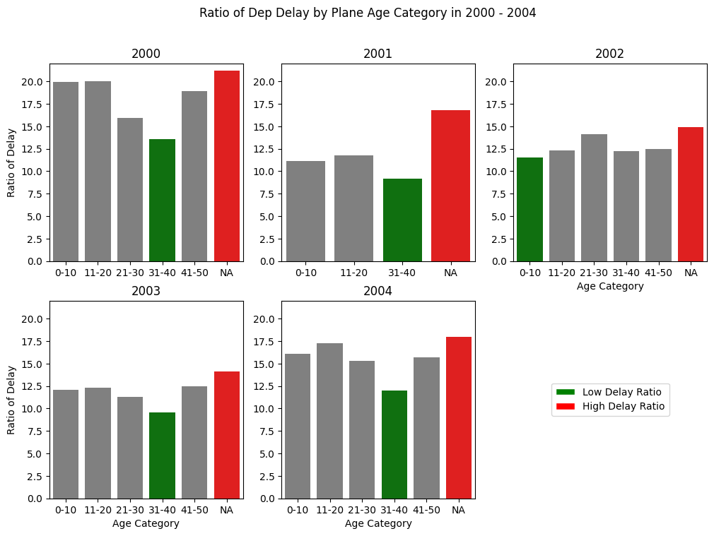

```python
fig, ax = plt.subplots(2,3, figsize= (12,8))
ax= ax.flatten()
sns.barplot(data= delaying_ratio[delaying_ratio['Year']==2000], x='Age_category', y= 'ratio_of_delay', ax=ax[0], hue= 'Age_category', palette=colours_cus_6[0])
ax[0].set_xlabel('')
ax[0].set_ylabel('Ratio of Delay')
ax[0].set_ylim(0,22)
ax[0].set_title('2000')
sns.barplot(data= delaying_ratio[delaying_ratio['Year']==2001], x='Age_category', y= 'ratio_of_delay', ax=ax[1], hue= 'Age_category', palette=colours_cus_6[1])
ax[1].set_xlabel('')
ax[1].set_ylabel('')
ax[1].set_ylim(0,22)
ax[1].set_title('2001')
sns.barplot(data= delaying_ratio[delaying_ratio['Year']==2002], x='Age_category', y= 'ratio_of_delay', ax=ax[2], hue= 'Age_category', palette=colours_cus_6[2])
ax[2].set_xlabel('Age Category')
ax[2].set_ylabel('')
ax[2].set_ylim(0,22)
ax[2].set_title('2002')
sns.barplot(data= delaying_ratio[delaying_ratio['Year']==2003], x='Age_category', y= 'ratio_of_delay', ax=ax[3], hue= 'Age_category', palette=colours_cus_6[3])
ax[3].set_xlabel('Age Category')
ax[3].set_ylabel('Ratio of Delay')
ax[3].set_ylim(0,22)
ax[3].set_title('2003')
sns.barplot(data= delaying_ratio[delaying_ratio['Year']==2004], x='Age_category', y= 'ratio_of_delay', ax=ax[4], hue= 'Age_category', palette=colours_cus_6[4])
ax[4].set_xlabel('Age Category')
ax[4].set_ylabel('')
ax[4].set_ylim(0,22)
ax[4].set_title('2004')
ax[5].axis('off')

leg_notes_6 = [Patch(facecolor = "green", edgecolor ="white", label="Low Delay Ratio"),
            Patch(facecolor = "red", edgecolor= "white", label ="High Delay Ratio")]
#this is to create manually the legend, where the color will be green and red to represents the Low Delay Ratio and High Delay Ratio respectively.
plt.legend(handles = leg_notes_6, loc = "center") #the legend will be plotted using the leg_notes_, that is located in the center

plt.suptitle("Ratio of Dep Delay by Plane Age Category in 2000 - 2004")
plt.show()
```

The bar plot will be shown, where high ratio will be shown as red and low ratio is shown as green.